# PSYC 559 Final Project: Predicting Daily Life Satisfaction on Gaming Days

Group 1

2026-11-26

**How to run this file.** This one file is the whole analysis. Knit it from start to finish; no other script has to be run first. It reads four files from the `data/` folder next to it:

- `openesm_0075.rds`, the Open Play daily diary from openESM. If it is missing, the `download` chunk downloads and saves it (this needs the internet).
- `survey_intake.csv.gz`, the Open Play intake survey from the project’s repository (https://github.com/digital-wellbeing/open-play), which supplies the demographics.
- `game_classification.csv` and `game_classification_excluded.csv`, the hand-reviewed lookup files that give each game title’s genre.

The file cleans the diary, builds the daily table, runs the clustering and the principal components, fits every supervised model on feature sets A and B, and saves the results to `output/final_results.rds` for the report. Fitting the models takes most of the knit time.

**The test set stays locked until the final model is chosen.** The chunks that touch the test set only run when `run_test_set` is `TRUE`. Keep it `FALSE` while reading the cross-validated comparison (Section 8), then set it to `TRUE` for one final knit.

```r
run_test_set <- TRUE
```

**Saved model fits.** Each `train()` result is saved to `output/model_fits/` as soon as it is fit. If the folder is missing, every model is fit from scratch. Later knits read the saved fit instead of refitting, so editing the text or the tables does not cost another long run: with the saved fits a knit takes a few minutes, and refitting every model took about 1.5 hours on a laptop with the folds in parallel. Set `refit_models` to `TRUE` (or delete the folder) whenever anything before Section 8 changes, and once more for the knit that is submitted (the handout: “knit clean before submitting”). The fits are exactly reproducible with the same package versions (Section 12), so that knit should give the same numbers.

```r
refit_models <- FALSE
```

```r
library(openesm)     # get_dataset() and cite()
library(dplyr)      # data manipulation and the pipe
library(tidyr)       # pivot_longer()
library(ggplot2)     # plots
library(naniar)      # vis_miss() and gg_miss_var()
library(rsample)     # group_initial_split()
library(recipes)     # imputation, dummy coding, and scaling inside the pipeline
library(cluster)     # silhouette()
library(caret)       # train(), groupKFold(), resamples(), varImp()
library(glmnet)      # elastic net
library(ranger)      # random forests
library(doParallel)  # fits the cross-validation folds in parallel

theme_set(theme_minimal(base_size = 12))

# Every file is read from data/ and written to output/, both in the folder
# that holds this Rmd. Knitting runs from that folder, and so does running
# chunks by hand after opening the .Rproj.
data_path <- function(file) file.path("data", file)
out_path  <- function(file) file.path("output", file)
dir.create("output", showWarnings = FALSE)
```

# 1. Research Questions

**Supervised.** Using same-day predictors and stable person characteristics from the intake survey, how well can we predict a player’s **life satisfaction** on a day they played video games? Life satisfaction is the daily item “I was satisfied with my life today,” rated on a 0 to 100 slider, so the target is **continuous**. The predictors are:

- the six Basic Needs in Games (BANGS) items about the most recent session;
- the type of game played and who the person played with that day;
- sleep quality, the type of day, and the platform;
- whether a stressful event occurred, which kinds, and how stressful the worst one was;
- six daily basic-needs items (satisfaction and frustration of autonomy, competence, and relatedness);
- demographics and life circumstances from the intake survey: age, gender, employment, education, relationship status, and caring for children.

Every daily predictor comes from the **same day’s** survey as the target, so the model describes what goes together on a day. It does not forecast. Affective valence (“How are you feeling right now?”) is **not** a predictor. It is answered in the same sitting and correlates highly with life satisfaction (Section 3).

The users are designers of digital well-being tools, such as a check-in at the end of a play session that flags players who may be having a bad day.

**Unsupervised.**

- **Dimensions of a day (PCA).** We reduce the six daily basic-needs items. We expect two components, general satisfaction and general frustration, rather than one per need.
- **Types of play days (K-means).** We cluster the play days on the six BANGS items, which describe the day’s most recent gaming session. The proposal expected days built around a “toxic competitive session,” a “low improvement session,” and a “satisfying solo session.”

# 2. Get the Data

## The download

The diary is the `get_dataset("0075")` output, downloaded once and saved to `data/openesm_0075.rds`.

```r
# only runs if the saved file is missing
open_play <- get_dataset("0075")
saveRDS(open_play, data_path("openesm_0075.rds"))
```

```r
open_play <- readRDS(data_path("openesm_0075.rds"))
raw <- open_play$data          # the diary as downloaded

intake <- read.csv(data_path("survey_intake.csv.gz"), stringsAsFactors = FALSE)

# the expected file: one row per person per day
dim(raw)
```

```
## [1] 16346    51
```

```r
stopifnot(nrow(raw) == 16346, n_distinct(raw$id) == 1284,
          !anyDuplicated(raw[c("id", "day")]))
c(people = n_distinct(raw$id))
```

```
## people
##   1284
```

The citation for the references section:

```r
cite(open_play)
```

## The codebook

The codebook comes with the data, one row per variable. The item wording is in `details` and the response codes are in `labels`.

```r
codebook <- open_play$metadata$features[[1]]

codebook %>%
  filter(name %in% c("gaming_toxic", "needs_autonomy_satisfied",
                     "life_satisfaction", "sleep_quality",
                     "how_stressful_health")) %>%
  mutate(across(c(details, labels), ~ gsub("\n", " ", .x))) %>%
  select(name, details, labels) %>%
  knitr::kable()
```

| name | details | labels |
| --- | --- | --- |
| gaming_toxic | Interactions with other players and/or characters felt toxic to me. | 1 = Strongly Disagree 4 = Neither Agree nor Disagree 7 = Strongly agree |
| needs_autonomy_satisfied | The next statements tap into your experiences today. Please indicate for each of the statements to what extent they are true for you.Today… … I was able to do things that I really want and value in li… | 1 = very strongly disagree 2 = strongly disagree 3 = disagree 4 = neither disagree nor agree 5 = agree 6 = strongly agree 7 = very strongly agree |
| how_stressful_health | How stressful was this event? Health issue | 1 = not at all 2 = not very 3 = somewhat 4 = very |
| life_satisfaction | I was satisfied with my life today. |  |
| sleep_quality | How do you rate the quality of your sleep? “Sleep Quality” is your sense of whether you slept well or poorly. | 1 = very poor 2 = poor 3 = fair 4 = good 5 = very good |

# 3. Build the Daily Table

## What is in a row

Open Play surveys once a day at 2 PM, so each row is already one person on one day (`beep` is always 1). No aggregation is needed and there is no minimum-prompts rule. The work is recoding and restricting to play days.

```r
table(beep = raw$beep)
```

```
## beep
##     1
## 16346
```

## Clean the diary

16,346 days are kept. The cleaning script does the following:

- **Checkboxes to No/Yes factors, with skip-pattern blanks recoded rather than imputed.** The social-play boxes are “No” on days without play. The stress event types are “No” on days without a stressful event.
- **Summaries.** The four social-play boxes were summarized into `play_context`, and the typed platform answers were grouped into `platform`, each with a “Did not play” level. The rules are listed later in this section.
- **Stress severity** (four options) is an ordered factor, and `stress_worst` is the highest severity that day.
- **Swapped columns fixed.** In the source data, the severity ratings for the “health” and “other” events are stored in each other’s columns. The cleaning swaps them back.
- **Type of day.** Holiday and vacation day are combined into one level.
- **Dropped:**
  - bookkeeping (`date`, `beep`, `survey_duration`, `baseline_day`, `ideal_baseline_day`, `n_valid`, `original_wave`);
  - the attention-check and duplicate-item columns for the needs scale;
  - free text (`most_recent_game`, `displaced_activity`).

```r
# 1. The swapped stress ratings. In the source data the "health" and "other"
# severity ratings sit in each other's columns: every day with the health box
# checked has its rating in how_stressful_other and none in
# how_stressful_health, and the reverse holds for "other". Check this, then
# swap them back. The swap is made on a copy, so raw stays as downloaded.
swap_check <- c(
  health_checked_other_rated = sum(!is.na(raw$stress_events_health) & !is.na(raw$how_stressful_other)),
  health_checked             = sum(!is.na(raw$stress_events_health)),
  other_checked_health_rated = sum(!is.na(raw$stress_events_other) & !is.na(raw$how_stressful_health)),
  other_checked              = sum(!is.na(raw$stress_events_other)))
swap_check
```

```
## health_checked_other_rated             health_checked
##                        531                        531
## other_checked_health_rated              other_checked
##                        594                        594
```

```r
stopifnot(swap_check[1] == swap_check[2], swap_check[3] == swap_check[4])

src <- raw %>%
  rename(how_stressful_health = how_stressful_other,
         how_stressful_other  = how_stressful_health)

# 2. Recode
yes_no <- function(x) factor(x, levels = c("No", "Yes"))

# A checkbox holds its label when checked and NA when not. On days the
# question was not shown (no play, no stress), unchecked means "No".
# `asked` is TRUE when shown, FALSE when skipped by design, and NA when the
# gate question itself is missing.
checkbox <- function(x, asked) {
  factor(ifelse(is.na(asked), NA, ifelse(!is.na(x), "Yes", "No")),
         levels = c("No", "Yes"))
}

social_cols <- c("social_singleplayer", "social_friends_realworld",
                 "social_friends_online", "social_strangers")
event_cols  <- grep("^stress_events_", names(src), value = TRUE)
sev_cols    <- grep("^how_stressful_", names(src), value = TRUE)
sev_levels  <- c("No event", "Not at all", "Not very", "Somewhat", "Very")

daily <- src %>%
  mutate(
    played24hr = yes_no(played24hr),
    had_stress = yes_no(had_stress),

    # who they played with: days without play are "No" for every box; a play
    # day with no box checked is NA (everyone who played, played with someone
    # or alone)
    no_social_box = rowSums(!is.na(across(all_of(social_cols)))) == 0,
    across(all_of(social_cols), ~ checkbox(.x, asked = played24hr == "Yes")),
    across(all_of(social_cols), ~ replace(.x, played24hr == "Yes" & no_social_box, NA)),

    # one summary of the social context, with its own level for non-play days
    play_context = case_when(
      played24hr == "No" ~ "Did not play",
      social_strangers == "Yes" &
        (social_friends_realworld == "Yes" | social_friends_online == "Yes") ~ "Friends + strangers",
      social_strangers == "Yes" ~ "Strangers only",
      social_friends_realworld == "Yes" | social_friends_online == "Yes" ~ "Friends only",
      social_singleplayer == "Yes" ~ "Solo only"),
    play_context = factor(play_context,
                          levels = c("Did not play", "Solo only", "Friends only",
                                     "Friends + strangers", "Strangers only")),

    # platform of the most recent session, grouped; typed "Other" answers
    # (PC, laptop, Chromebook, ...) stay "Other"
    platform = case_when(
      played24hr == "No" ~ "Did not play",
      most_recent_game_plat == "Steam"       ~ "Steam",
      most_recent_game_plat == "Xbox"        ~ "Xbox",
      most_recent_game_plat == "Playstation" ~ "PlayStation",
      grepl("^Nintendo", most_recent_game_plat) ~ "Nintendo",
      most_recent_game_plat %in% c("iOS", "Android", "AMAZON TABLET") ~ "Mobile",
      !is.na(most_recent_game_plat) ~ "Other"),
    platform = factor(platform, levels = c("Did not play", "Steam", "Xbox",
                                           "PlayStation", "Nintendo",
                                           "Mobile", "Other")),

    # stress event types: "No" on days with had_stress = "No"; NA on a "Yes"
    # day with no type checked (the types are unknown)
    any_event_box = rowSums(!is.na(across(all_of(event_cols)))) > 0,
    across(all_of(event_cols), ~ checkbox(.x, asked = had_stress == "Yes")),
    across(all_of(event_cols), ~ replace(.x, had_stress == "Yes" & !any_event_box, NA)),
    n_stress_events = rowSums(across(all_of(event_cols), ~ .x == "Yes")),

    # severity (1 to 4 in the source) as an ordered factor with a "No event"
    # level below "Not at all": four response options, so not numeric
    worst_raw = suppressWarnings(
      do.call(pmax, c(across(all_of(sev_cols)), na.rm = TRUE))),
    across(all_of(sev_cols),
           ~ factor(ifelse(is.na(had_stress), NA, ifelse(is.na(.x), 0, .x)),
                    levels = 0:4, labels = sev_levels, ordered = TRUE)),
    across(all_of(sev_cols), ~ replace(.x, had_stress == "Yes" & !any_event_box, NA)),
    stress_worst = factor(case_when(
      had_stress == "No"  ~ 0,
      had_stress == "Yes" ~ worst_raw),    # NA if "Yes" but nothing rated
      levels = 0:4, labels = sev_levels, ordered = TRUE),

    # type of day: holiday and vacation day (2 to 3% of days each) both mean a
    # weekday off, so they are combined
    day_type = factor(day_type,
                      levels = c("Regular work day", "Regular day off", "Weekend",
                                 "Holiday", "Vacation day", "Other (please specify):"),
                      labels = c("Work day", "Day off", "Weekend",
                                 "Holiday or vacation", "Holiday or vacation", "Other"))
    # numeric items stay numbers: gaming_* and needs_* (1 to 7), sleep_quality
    # (1 to 5), affective_valence and life_satisfaction (0 to 100)
  )

# an event type that was checked must have a severity rating, and only then
for (e in sub("stress_events_", "", event_cols)) {
  sev <- if (e == "home") "how_stressful_home_issue" else paste0("how_stressful_", e)
  stopifnot(all((daily[[paste0("stress_events_", e)]] == "Yes") ==
                  (daily[[sev]] > "No event"), na.rm = TRUE))
}

# 3. Keep the variables, one row per person per day, in id and day order
daily <- daily %>%
  arrange(id, day) %>%
  select(id, day, affective_valence, life_satisfaction, sleep_quality, day_type,
         played24hr, starts_with("gaming_"), all_of(social_cols), play_context, platform,
         starts_with("needs_"),
         had_stress, all_of(event_cols), n_stress_events, all_of(sev_cols), stress_worst)

# the clean table has the same person days as the download
stopifnot(nrow(daily) == nrow(raw),
          setequal(paste(daily$id, daily$day), paste(raw$id, raw$day)))
dim(daily)
```

```
## [1] 16346    42
```

The attention check failed on no day, so dropping it loses nothing:

```r
table(bpnsfs_failed_att_check = raw$bpnsfs_failed_att_check, useNA = "ifany")
```

```
## bpnsfs_failed_att_check
## FALSE
## 16346
```

## What the analysis adds

**Added back from the download** (joined by `id` and `day`):

- `most_recent_game`, used once to build the game type (below). It is not a predictor.
- `date`, used only for two checks: platform missingness by month (Section 4) and the intake-timing leakage check (Section 7).

**Left out of the analysis:**

- **Affective valence** (“How are you feeling right now?”). It is answered in the same sitting as life satisfaction and is close to the same thing on a given day (correlation below). A model that used it would mostly translate valence into life satisfaction. It is the target in another form.
- **`n_stress_events` and the seven individual severity ratings.** The stress information enters as `had_stress`, the seven event types, and the worst rating that day.
- **The four social-play checkboxes.** They enter through `play_context`.
- **Lags.** Every predictor here is from the same day, so no lags are built.

```r
round(cor(daily$affective_valence, daily$life_satisfaction, use = "complete.obs"), 2)
```

```
## [1] 0.87
```

```r
dat <- daily %>%
  select(-affective_valence, -n_stress_events, -starts_with("how_stressful_")) %>%
  left_join(raw %>% select(id, day, date, most_recent_game), by = c("id", "day"))

stopifnot(nrow(dat) == nrow(daily))
dim(dat)
```

```
## [1] 16346    35
```

## Play days only

The six BANGS items are asked only on days the person played in the last 24 hours. Our question is about play days, so the daily table keeps only those days, as the proposal says. Days with a missing answer to the play question are dropped with them.

```r
table(played24hr = dat$played24hr, useNA = "always")
```

```
## played24hr
##    No   Yes  <NA>
##  3640 12435   271
```

```r
# BANGS items exist only on play days
table(played = dat$played24hr, has_bangs = !is.na(dat$gaming_toxic), useNA = "ifany")
```

```
##       has_bangs
## played FALSE  TRUE
##   No    3640     0
##   Yes     26 12409
##   <NA>   271     0
```

```r
counts <- data.frame(step = "All diary days",
                     days = nrow(dat), people = n_distinct(dat$id))

# days with no answer to the play question, and how many also lack the target
played_missing <- c(days      = sum(is.na(dat$played24hr)),
                    no_target = sum(is.na(dat$played24hr) & is.na(dat$life_satisfaction)))
played_missing
```

```
##      days no_target
##       271       248
```

```r
dat <- dat %>%
  filter(played24hr %in% "Yes") %>%
  select(-played24hr) %>%
  mutate(play_context = droplevels(play_context),   # "Did not play" no longer occurs
         platform     = droplevels(platform))

counts <- rbind(counts, data.frame(step = "Play days",
                                   days = nrow(dat), people = n_distinct(dat$id)))

# no play day was left with the non-play levels
stopifnot(!any(c(levels(dat$play_context), levels(dat$platform)) == "Did not play"))
```

The 271 days with no answer to the play question are nearly all empty surveys. 248 of them have no life satisfaction rating either, so they could not have been used anyway.

**Play days with no gaming answers.** On some play days the person said they played, then skipped every gaming question: no title, no social box, no platform, and no BANGS item. These days are dropped:

- The question is about what a day of gaming was like, and these days say nothing about it. Every gaming predictor would be imputed, so each day would add filled-in values, not information.
- They would also be miscoded. A blank title is “Unclassified,” and the game-type rules (below) read a missing play context as solo.

```r
bangs <- c("gaming_autonomy", "gaming_wish_else", "gaming_progress",
           "gaming_disappointed", "gaming_relationships", "gaming_toxic")
needs <- c("needs_autonomy_satisfied", "needs_autonomy_frustrated",
           "needs_competence_satisfied", "needs_competence_frustrated",
           "needs_relatedness_satisfied", "needs_relatedness_frustrated")

no_title  <- is.na(dat$most_recent_game) | trimws(dat$most_recent_game) == ""
no_gaming <- no_title & is.na(dat$play_context) & is.na(dat$platform) &
             rowSums(!is.na(dat[bangs])) == 0

no_gaming_n <- c(days = sum(no_gaming),
                 with_target = sum(no_gaming & !is.na(dat$life_satisfaction)))
no_gaming_n
```

```
##        days with_target
##          16           4
```

```r
dat <- dat[!no_gaming, ]

counts <- rbind(counts, data.frame(step = "Play days with gaming answers",
                                   days = nrow(dat), people = n_distinct(dat$id)))
counts
```

| step | days | people |
| --- | --- | --- |
| All diary days | 16346 | 1284 |
| Play days | 12435 | 1171 |
| Play days with gaming answers | 12419 | 1170 |

16 play days had no gaming answers. Only 4 of them had a life satisfaction rating, so dropping them loses 4 usable days.

## Checking the recoding

**Placeholder codes.** The numeric items are all inside their allowed ranges, so there are no codes like 99 or -99:

```r
sapply(dat[c("life_satisfaction", bangs, needs, "sleep_quality")], range, na.rm = TRUE)
```

```
##      life_satisfaction gaming_autonomy gaming_wish_else gaming_progress
## [1,]                 0               1                1               1
## [2,]               100               7                7               7
##      gaming_disappointed gaming_relationships gaming_toxic
## [1,]                   1                    1            1
## [2,]                   7                    7            7
##      needs_autonomy_satisfied needs_autonomy_frustrated
## [1,]                        1                         1
## [2,]                        7                         7
##      needs_competence_satisfied needs_competence_frustrated
## [1,]                          1                           1
## [2,]                          7                           7
##      needs_relatedness_satisfied needs_relatedness_frustrated sleep_quality
## [1,]                           1                            1             1
## [2,]                           7                            7             5
```

```r
sapply(dat[c("life_satisfaction", bangs, needs, "sleep_quality")], class)
```

```
##            life_satisfaction              gaming_autonomy
##                    "numeric"                    "numeric"
##             gaming_wish_else              gaming_progress
##                    "numeric"                    "numeric"
##          gaming_disappointed         gaming_relationships
##                    "numeric"                    "numeric"
##                 gaming_toxic     needs_autonomy_satisfied
##                    "numeric"                    "numeric"
##    needs_autonomy_frustrated   needs_competence_satisfied
##                    "numeric"                    "numeric"
##  needs_competence_frustrated  needs_relatedness_satisfied
##                    "numeric"                    "numeric"
## needs_relatedness_frustrated                sleep_quality
##                    "numeric"                    "numeric"
```

**Ordinal items** follow one rule. An item with five or more ordered response options is treated as numeric, and one with fewer is treated as an ordered factor.

- The BANGS and needs items (1 to 7) and sleep quality (1 to 5) are numeric.
- The worst-stressor rating has four options, so it is an ordered factor (below).

**Type of day**, with holiday and vacation already combined:

```r
table(dat$day_type, useNA = "always")
```

```
##
##            Work day             Day off             Weekend Holiday or vacation
##                5366                4120                1688                 652
##               Other                <NA>
##                 583                  10
```

**Who they played with and the platform.** These were summarized in the cleaning (Section 3) with these rules:

- play context is friends + strangers, strangers only, friends only, or solo only;
- iOS and Android are combined as Mobile, and typed “Other” platforms stay Other.

A play day with no social box checked would have a missing play context. Every such day also had no other gaming answers and was dropped above, so none remain.

```r
table(dat$play_context, useNA = "always")
```

```
##
##           Solo only        Friends only Friends + strangers      Strangers only
##                5391                3363                1252                2413
##                <NA>
##                   0
```

```r
table(dat$platform, useNA = "always")
```

```
##
##       Steam        Xbox PlayStation    Nintendo      Mobile       Other
##        5767        1457         500        1048         993        1907
##        <NA>
##         747
```

## Type of game

`most_recent_game` is typed free text. We clean each title (lowercase, accents removed, punctuation stripped) and look up its genre in two files:

- `game_classification.csv`, a hand-reviewed list of titles and genres;
- `game_classification_excluded.csv`, the titles that were only named on solo days or are single-player games. These were classified by matching patterns in the titles and not reviewed by hand.

Each genre is then coded by **who the other people in the game are**:

- single-player;
- non-competitive (co-op, MMO, sandbox, casual);
- individual competition;
- team competition;
- unknown.

**On days with other players** (friends, strangers, or both), these rules apply:

- Games that can be played either solo or in a squad (Fortnite, PUBG, Warzone), Minecraft, and Roblox are coded from who the person played with: with friends, team competition; strangers only, individual competition.
- Single-player games with a co-op mode count as non-competitive.
- Titles neither lookup file can classify are “Unknown.”

**On solo-only days, the person’s own answer decides.** On a solo-only day the person answered “Single-player games only” when asked what kind of social interaction they took part in while gaming. Every game on such a day is coded **single-player**, whatever its genre in the lookup files. The reasons:

- **The lookup only says what a game can be.** Many games coded as competitive or co-op also have modes played alone or against the computer (Call of Duty, Mario Kart, WWE 2K25, Minecraft, Genshin Impact). The person knows which mode they played. The lookup does not.
- **The session items are answered from the person’s own view of the session.** The BANGS items (relationships, toxicity, disappointment) ask how the most recent session felt. They have to be read in the context the person reported, not in one we assign from the title.
- **We do not overrule what people said in the survey.** Where the person’s description of their gaming day and our classification of the game disagree, the person’s description wins.
- **It also covers titles the lookup cannot classify.** The solo-day titles come from the lookup file that was not reviewed by hand, which leaves many single-player games “Unclassified” (Pokémon Shield, Final Fantasy VII Rebirth, Civilization). And it removes cases where similar games got different codes (College Football 25 as individual competition, College Football 26 as unclassified).

The table after the chunk shows what the genre rules would have given on the solo-only days.

```r
clean_name <- function(x) {
  x <- iconv(x, from = "UTF-8", to = "ASCII//TRANSLIT", sub = "")
  x <- gsub("[^a-z0-9 ]", " ", tolower(x))
  x <- trimws(gsub("[[:space:]]+", " ", x))
  x[is.na(x)] <- ""
  x
}

# the reviewed list comes first, so its genre wins if a title is in both files
lookup_cols  <- c("game", "genre", "classified_by")
genre_lookup <- rbind(
  read.csv(data_path("game_classification.csv"), stringsAsFactors = FALSE)[, lookup_cols],
  read.csv(data_path("game_classification_excluded.csv"), stringsAsFactors = FALSE)[, lookup_cols])
genre_lookup <- genre_lookup[!duplicated(genre_lookup$game), ]

# a title missing from both files stops the knit rather than being guessed
genre_of <- function(name) {
  genre <- genre_lookup$genre[match(name, genre_lookup$game)]
  if (anyNA(genre)) stop("Not in the lookup files: ",
                         paste(unique(name[is.na(genre)]), collapse = ", "))
  genre
}

# answers that name more than one game; each game is classified on its own
multi_game <- list(
  "baldurs gate 3 echoes of the plum grove" = c("baldurs gate 3", "echoes of the plum grove"),
  "btd 6 roblox"                       = c("btd 6", "roblox"),
  "btd 6 rematch"                      = c("btd 6", "rematch"),
  "btd 6 warframe roblox"              = c("btd 6", "warframe", "roblox"),
  "btd 6 warframe roblox terraria"     = c("btd 6", "warframe", "roblox", "terraria"),
  "dbd roblox"                         = c("dbd", "roblox"),
  "dead by daylight and roblox"        = c("dead by daylight", "roblox"),
  "dune awakening erenshor"            = c("dune awakening", "erenshor"),
  "expedition 33 and fortnite"         = c("expedition 33", "fortnite"),
  "fallout 4 dead by daylight"         = c("fallout 4", "dead by daylight"),
  "fornite and rocket league"          = c("fortnite", "rocket league"),
  "fortnite and avowed"                = c("fortnite", "avowed"),
  "fortnite and battle teams 2"        = c("fortnite", "battle teams 2"),
  "fortnite call of duty"              = c("fortnite", "call of duty"),
  "gta v and schedule 1"               = c("gta v", "schedule 1"),
  "marvel rivals and roblox"           = c("marvel rivals", "roblox"),
  "marvel rivals smurfvillage"         = c("marvel rivals", "smurfs village"),
  "marvel snap supervive"              = c("marvel snap", "supervive"),
  "minecraft and marvel rivals"        = c("minecraft", "marvel rivals"),
  "minecraft bf4 nhl 25"               = c("minecraft", "battlefield 4", "nhl"),
  "minecraft roblox"                   = c("minecraft", "roblox"),
  "mix of shcedule 1 and game of thrones" = c("schedule 1", "game of thrones"),
  "nba 2k25 wwe 2k25"                  = c("nba 2k25", "wwe 2k25"),
  "nhl 25 minecraft and battlefield 4" = c("nhl", "minecraft", "battlefield 4"),
  "no man s sky deep rock galactic"    = c("no man s sky", "deep rock galactic"),
  "pokemon go and royal match"         = c("pokemon go", "royal match"),
  "powerwashing simulator club penguin" = c("powerwash simulator", "club penguin"),
  "roblox btd 6"                       = c("roblox", "btd 6"),
  "roblox btd 6 limbus company"        = c("roblox", "btd 6", "limbus company"),
  "roblox btd 6 osrs"                  = c("roblox", "btd 6", "osrs"),
  "roblox fortnite"                    = c("roblox", "fortnite"),
  "sun haven coral island"             = c("sun haven", "coral island"),
  "sun haven echoes of the plum grove" = c("sun haven", "echoes of the plum grove"),
  "the walking dead fortnite"          = c("the walking dead", "fortnite"),
  "word find stud io poker"            = c("word find", "poker"))
```

```r
code_competition <- function(game_category, play_context) {
  with_friends <- play_context %in% c("Friends only", "Friends + strangers")
  with_others  <- with_friends | play_context %in% "Strangers only"
  case_when(
    game_category == "Solo or co-op" & with_others ~ "Non-competitive",
    game_category == "Solo or co-op" ~ "Single-player",
    game_category == "Competitive team" ~ "Team competition",
    game_category == "Squad or solo" & with_friends ~ "Team competition",
    game_category == "Squad or solo" ~ "Individual competition",
    game_category == "Head-to-head" ~ "Individual competition",
    game_category %in% c("Online co-op / MMO", "Sandbox / social",
                         "Casual / mobile") ~ "Non-competitive",
    game_category %in% c("Minecraft", "Roblox") & with_friends ~ "Team competition",
    game_category %in% c("Minecraft", "Roblox") & with_others ~ "Individual competition",
    game_category %in% c("Minecraft", "Roblox") ~ "Non-competitive",
    game_category == "Mobile (single-player)" ~ "Single-player",
    game_category == "Single-player" ~ "Single-player",
    TRUE ~ "Unknown")
}

# several games named: on days with others, single-player games are dropped;
# if the games left agree the day gets their code, otherwise "Unknown"
combine_games <- function(name, play_context) {
  codes <- unique(code_competition(genre_of(multi_game[[name]]), play_context))
  with_others <- play_context %in% c("Friends only", "Friends + strangers",
                                     "Strangers only")
  if (with_others && any(codes != "Single-player")) {
    codes <- setdiff(codes, "Single-player")
  }
  if (length(codes) == 1) codes else "Unknown"
}

# code_competition() reads a missing play context as solo, so a missing context
# is allowed only on days with no title (no gaming answers at all)
stopifnot(all(clean_name(dat$most_recent_game)[is.na(dat$play_context)] == ""))

dat <- dat %>%
  mutate(game_clean    = clean_name(most_recent_game),
         game_category = genre_of(game_clean),
         game_type     = code_competition(game_category, play_context))

several <- dat$game_category == "Multiple games"
dat$game_type[several] <- mapply(combine_games, dat$game_clean[several],
                                 as.character(dat$play_context[several]))

# the solo-day rule: on a "single-player games only" day, every game is
# single-player. First, what the genre rules alone gave on those days:
solo_day <- dat$play_context %in% "Solo only"
solo_rule <- table(genre_rules_gave = dat$game_type[solo_day])
solo_rule
```

```
## genre_rules_gave
## Individual competition        Non-competitive          Single-player
##                    256                    586                   3424
##       Team competition                Unknown
##                     57                   1068
```

```r
dat$game_type[solo_day] <- "Single-player"

dat$game_type <- factor(dat$game_type,
                        levels = c("Single-player", "Non-competitive",
                                   "Individual competition", "Team competition",
                                   "Unknown"))

table(dat$game_type, useNA = "always")
```

```
##
##          Single-player        Non-competitive Individual competition
##                   6225                   2619                   1061
##       Team competition                Unknown                   <NA>
##                   2480                     34                      0
```

```r
# how the game type lines up with who the person played with
table(play_context = dat$play_context, game_type = dat$game_type, useNA = "ifany")
```

```
##                      game_type
## play_context          Single-player Non-competitive Individual competition
##   Solo only                    5391               0                      0
##   Friends only                  341            1502                    283
##   Friends + strangers           153             403                    178
##   Strangers only                340             714                    600
##                      game_type
## play_context          Team competition Unknown
##   Solo only                          0       0
##   Friends only                    1218      19
##   Friends + strangers              516       2
##   Strangers only                   746      13
```

Of the 5,391 solo-only days, the genre rules alone would have given 899 a competitive or non-competitive code and left 1,068 unknown. The person’s answer codes them all as single-player. Game type and play context now overlap on these days by design, so the importance of the two (Section 9) should be read together.

On days with other players, the most recent game can still be a single-player game (834 days). That is not a contradiction. The play context covers the whole day, while the game type describes the most recent session.

## Stress

The stress predictors are:

- `had_stress` (“Did anything happen to you in the last 24 hours that most people would consider stressful?”);
- the seven event types as No/Yes factors;
- `stress_worst`, the highest severity rating that day, as an ordered factor.

The coding rules:

- **Event types.** “No” on a day the stress question was answered “No.” Missing on a day the stress question itself is missing. Otherwise “Yes” if the box was checked and “No” if not.
- **Worst stressor.**
  - “None” if there was no stressful event.
  - Otherwise the highest severity rating, where the scale runs 1 = not at all to 4 = very.
  - Missing if the person said “Yes” but rated no event.
  - It is an ordered factor because the scale has only four options.

The group’s cleaning (above) built these columns with the same rules. The chunk below rebuilds both from the download with the rules above and checks that every play day agrees.

```r
event_cols <- grep("^stress_events_", names(dat), value = TRUE)

# the gate question and the follow-ups agree: every "Yes" has a type checked
table(had_stress = dat$had_stress,
      any_type_yes = rowSums(sapply(dat[event_cols], function(x) x == "Yes")) > 0,
      useNA = "ifany")
```

```
##           any_type_yes
## had_stress FALSE  TRUE  <NA>
##       No   10612     0     0
##       Yes      0  1798     0
##       <NA>     0     0     9
```

```r
# the rules above applied to the download, play days only
raw_play <- raw[match(paste(dat$id, dat$day), paste(raw$id, raw$day)), ]
rule_types <- sapply(event_cols, function(v)
  ifelse(is.na(raw_play$had_stress), NA, ifelse(!is.na(raw_play[[v]]), "Yes", "No")))
sev   <- as.matrix(raw_play[grep("^how_stressful_", names(raw_play))])
worst <- suppressWarnings(apply(sev, 1, max, na.rm = TRUE))
rule_worst <- ifelse(raw_play$had_stress == "No", 0,
                   ifelse(raw_play$had_stress == "Yes" & rowSums(!is.na(sev)) > 0,
                          worst, NA))

# same answers on every play day
stopifnot(identical(unname(rule_types), unname(sapply(dat[event_cols], as.character))))
stopifnot(identical(as.numeric(rule_worst),
                    as.numeric(as.integer(dat$stress_worst) - 1)))   # "No event" = 0

table(rules_above = rule_worst, group_cleaning = dat$stress_worst, useNA = "ifany")
```

```
##            group_cleaning
## rules_above No event Not at all Not very Somewhat  Very  <NA>
##        0       10612          0        0        0     0     0
##        1           0          2        0        0     0     0
##        2           0          0      218        0     0     0
##        3           0          0        0      936     0     0
##        4           0          0        0        0   642     0
##        <NA>        0          0        0        0     0     9
```

The two codings agree on every play day. Two notes on the check:

- **The rule for a “Yes” with no type checked.** The group’s cleaning makes the event types missing on such a day, while the rules above code them “No.” The first table above shows that no play day has this pattern, so the two rules give the same data here.
- **The health/other swap.** The swap that the cleaning fixes does not change either column used here. The worst rating is the highest across all seven severity columns, whichever column a rating sits in. The event types come from the checkboxes, not the severity columns.

**Merging “Not at all” into “Not very.”** The worst-stressor factor has four levels: None < Not very < Somewhat < Very. Only 2 play days have “Not at all” as their worst rating. We code those days as “Not very” for three reasons:

1. **Two days cannot support a level of their own.** The elastic net would estimate a contrast from two days, which is noise. With ten grouped folds, the level would be missing entirely from most folds’ training or held-out data. The forest’s smallest leaf is five days, so it could never isolate them.
2. **“Not very” is the nearest level.** Both mean the event was mild, and the two are neighbors on the ordered scale. Merging neighbors keeps the order that makes the variable ordinal.
3. **“None” would be wrong.** The person did report a stressful event, and that day’s event types say so. Coding the worst rating “None” would contradict those columns on the same day.

The cost is negligible: two days out of 12,419.

```r
# shorter names for the event types
dat <- dat %>%
  rename(stress_argument       = stress_events_argument,
         stress_discrimination = stress_events_discrimination,
         stress_friend_family  = stress_events_friend_rel,
         stress_health         = stress_events_health,
         stress_home           = stress_events_home,
         stress_other          = stress_events_other,
         stress_work_school    = stress_events_work_school)

stress_types <- c("stress_argument", "stress_discrimination",
                  "stress_friend_family", "stress_health", "stress_home",
                  "stress_work_school", "stress_other")

# four levels; the duplicated label merges "Not at all" into "Not very"
dat$stress_worst <- factor(as.character(dat$stress_worst),
                           levels = c("No event", "Not at all", "Not very",
                                      "Somewhat", "Very"),
                           labels = c("None", "Not very", "Not very",
                                      "Somewhat", "Very"),
                           ordered = TRUE)

table(dat$stress_worst, useNA = "always")
```

```
##
##     None Not very Somewhat     Very     <NA>
##    10612      220      936      642        9
```

```r
# share of play days with each kind of event
sapply(dat[stress_types], function(x) round(100 * mean(x == "Yes", na.rm = TRUE), 1))
```

```
##       stress_argument stress_discrimination  stress_friend_family
##                   3.2                   0.3                   2.4
##         stress_health           stress_home    stress_work_school
##                   3.2                   3.2                   2.7
##          stress_other
##                   3.6
```

## Person characteristics from the intake survey

The intake survey came before the diary. The demographics are coded as follows:

- **Age** is in years.
- **Gender** is man, woman, or non-binary / gender diverse. Typed answers are coded by the identity they state.
- **Employment** is full-time, part-time or self-employed, student, or not employed.
- **Education** is the highest level completed, numeric 1 to 6 (six ordered levels).
- **Relationship status** is single, partnered, or divorced / separated / widowed.
- **Cares for children** is yes if that caregiving box was checked, and no if the person answered the question without checking it.

“Prefer not to say” is a non-answer and becomes missing (Section 4).

```r
blank_na <- function(x) { x <- trimws(x); x[x == ""] <- NA; x }

emp <- tolower(blank_na(intake$employment))
ms  <- tolower(blank_na(intake$marital_status))
edu <- blank_na(intake$edu_level)

care_cols <- c("care_children", "care_elderly", "care_disability",
               "care_none", "care_other")
answered_care <- rowSums(!is.na(intake[care_cols]) & intake[care_cols] != "") > 0

person <- data.frame(
  id  = intake$pid,
  age = intake$age,
  gender = case_when(
    intake$gender %in% c("Man", "Transgender Man", "Transgender Man (FTM)") ~ "Man",
    intake$gender %in% c("Woman", "trans woman") ~ "Woman",
    intake$gender == "Prefer not to say" | is.na(blank_na(intake$gender)) ~ NA_character_,
    TRUE ~ "Non-binary / gender diverse"),
  employment = case_when(
    is.na(emp) | grepl("prefer not", emp)              ~ NA_character_,
    grepl("student", emp)                               ~ "Student",
    emp %in% c("working full-time", "military")         ~ "Full-time",
    emp == "working part-time" |
      grepl("self|freelanc|gig|streamer|prolific", emp) ~ "Part-time / self-employed",
    TRUE                                                ~ "Not employed"),
  education = case_when(
    edu %in% c("Less than a high school diploma or equivalent",
               "Completed Primary School")                    ~ 1,
    edu %in% c("High school graduate or equivalent",
               "Completed Secondary School")                  ~ 2,
    edu %in% c("Some college but no degree",
               "Some University but no degree",
               "Vocational or Similar")                       ~ 3,
    edu == "Associate degree"                                 ~ 4,
    edu %in% c("Bachelor's degree", "University Bachelors Degree") ~ 5,
    edu %in% c("Master's degree, professional degree, or doctoral degree",
               "Graduate or professional degree (MA, MS, MBA, PhD, etc)") ~ 6,
    TRUE                                                      ~ NA_real_),
  relationship = case_when(
    is.na(ms) | ms == "prefer not to say"                     ~ NA_character_,
    ms == "single, never married"                             ~ "Single",
    grepl("divorc|widow|^separated", ms)                      ~ "Divorced / separated / widowed",
    grepl("married|partner|engaged|relationship|living with|civil union", ms) ~ "Partnered",
    TRUE                                                      ~ NA_character_),
  cares_for_children = case_when(
    !is.na(intake$care_children) & intake$care_children != "" ~ "Yes",
    answered_care                                             ~ "No",
    TRUE                                                      ~ NA_character_),
  intake_date = intake$date,
  stringsAsFactors = FALSE) %>%
  filter(id %in% dat$id)

# one intake record per person, so the join cannot duplicate days
stopifnot(!anyDuplicated(person$id))

# every typed answer and where it went, for the people in the daily table
in_dat <- intake$pid %in% dat$id
table(intake$employment[in_dat], person$employment[match(intake$pid[in_dat], person$id)],
      useNA = "ifany")
```

```
##
##                                                  Full-time Not employed
##   A homemaker or stay-at-home parent                     0           45
##   Caregiver                                              0            1
##   disabled                                               0            2
##   Disabled                                               0            7
##   Freelance                                              0            0
##   Freelance/self-employed                                0            0
##   freelancer                                             0            0
##   Freelancer                                             0            0
##   Gig work                                               0            0
##   Legally disabled/unable to work                        0            1
##   Long term illness                                      0            1
##   military                                               1            0
##   Not currently employed                                 0          237
##   prefer not to say                                      0            0
##   Prolific                                               0            0
##   Retired                                                0            1
##   Seeking employment, but not currently employed         0            1
##   Self-Emloyed (variable hours)/disabled                 0            0
##   Self-employed                                          0            0
##   self-employed, freelancer                              0            0
##   self employed                                          0            0
##   Self Employed                                          0            0
##   self employed freelancer                               0            0
##   Streamer                                               0            0
##   Student                                                0            0
##   student and working part time                          0            0
##   Student working part time                              0            0
##   Temporarily off work due to disability                 0            1
##   Working full-time                                    437            0
##   Working on prolific                                    0            0
##   Working part-time                                      0            0
##   <NA>                                                   0            0
##
##                                                  Part-time / self-employed
##   A homemaker or stay-at-home parent                                     0
##   Caregiver                                                              0
##   disabled                                                               0
##   Disabled                                                               0
```

[output cut: 47 more lines]

```
##   Self-Emloyed (variable hours)/disabled               0    0
##   Self-employed                                        0    0
##   self-employed, freelancer                            0    0
##   self employed                                        0    0
##   Self Employed                                        0    0
##   self employed freelancer                             0    0
##   Streamer                                             0    0
##   Student                                            179    0
##   student and working part time                        1    0
##   Student working part time                            1    0
##   Temporarily off work due to disability               0    0
##   Working full-time                                    0    0
##   Working on prolific                                  0    0
##   Working part-time                                    0    0
##   <NA>                                                 0    1
```

```r
table(intake$marital_status[in_dat], person$relationship[match(intake$pid[in_dat], person$id)],
      useNA = "ifany")
```

```
##
##                                                                               Divorced / separated / widowed
##   Divorced                                                                                                18
##   engaged                                                                                                  0
##   Engaged                                                                                                  0
##   Engaged, to be Married                                                                                   0
##   In a domestic partnership or civil union                                                                 0
##   In a long term relationship                                                                              0
##   in a relationship                                                                                        0
##   In a relationship                                                                                        0
##   In a Relationship                                                                                        0
##   In a relationship, not living together                                                                   0
##   In long-term relationship                                                                                0
##   in relationship, never married                                                                           0
##   Living with partner                                                                                      0
##   living with significant other                                                                            0
##   Long term relationship                                                                                   0
##   Long Term Relationship with a British Citizen, living separately                                         0
##   Married                                                                                                  0
##   Prefer not to say                                                                                        0
##   Separated                                                                                                7
##   Separated, intent to divorce, polyamorous relationship with another partner                              1
##   Single, never married                                                                                    0
##
##                                                                               Partnered
##   Divorced                                                                            0
##   engaged                                                                             2
##   Engaged                                                                             6
##   Engaged, to be Married                                                              1
##   In a domestic partnership or civil union                                          113
##   In a long term relationship                                                         1
##   in a relationship                                                                   1
##   In a relationship                                                                   3
##   In a Relationship                                                                   1
##   In a relationship, not living together                                              1
##   In long-term relationship                                                           1
##   in relationship, never married                                                      1
##   Living with partner                                                                 1
##   living with significant other                                                       1
##   Long term relationship                                                              1
```

[output cut: 37 more lines]

```
##   in a relationship                                                              0
##   In a relationship                                                              0
##   In a Relationship                                                              0
##   In a relationship, not living together                                         0
##   In long-term relationship                                                      0
##   in relationship, never married                                                 0
##   Living with partner                                                            0
##   living with significant other                                                  0
##   Long term relationship                                                         0
##   Long Term Relationship with a British Citizen, living separately               0
##   Married                                                                        0
##   Prefer not to say                                                              9
##   Separated                                                                      0
##   Separated, intent to divorce, polyamorous relationship with another partner    0
##   Single, never married                                                          0
```

```r
n_before <- nrow(dat)

dat <- dat %>%
  left_join(person, by = "id") %>%
  mutate(gender       = factor(gender, levels = c("Man", "Woman",
                                                  "Non-binary / gender diverse")),
         employment   = factor(employment, levels = c("Full-time",
                                                      "Part-time / self-employed",
                                                      "Student", "Not employed")),
         relationship = factor(relationship, levels = c("Single", "Partnered",
                                                        "Divorced / separated / widowed")),
         cares_for_children = factor(cares_for_children, levels = c("No", "Yes")))

stopifnot(nrow(dat) == n_before)

# people in the daily table with no intake record
c(people_without_intake = sum(!unique(dat$id) %in% intake$pid))
```

```
## people_without_intake
##                    46
```

## The daily table

```r
day_preds <- c("game_type", "play_context", "platform", "sleep_quality",
               "day_type", "had_stress", stress_types, "stress_worst")
person_preds <- c("age", "gender", "employment", "education", "relationship",
                  "cares_for_children")

days <- dat[c("id", "day", "date", "intake_date", "life_satisfaction",
              bangs, needs, day_preds, person_preds)]

dim(days)
```

```
## [1] 12419    37
```

```r
str(days)
```

```
## tibble [12,419 × 37] (S3: tbl_df/tbl/data.frame)
##  $ id                          : chr [1:12419] "p100362329" "p100362329" "p100362329" "p100362329" ...
##  $ day                         : num [1:12419] 1 2 3 4 5 6 7 1 2 3 ...
##  $ date                        : POSIXct[1:12419], format: "2024-10-02 14:23:32" "2024-10-03 19:09:00" ...
##  $ intake_date                 : chr [1:12419] "2024-09-26T19:20:41Z" "2024-09-26T19:20:41Z" "2024-09-26T19:20:41Z" "2024-09-26T19:20:41Z" ...
##  $ life_satisfaction           : num [1:12419] 65 80 75 67 75 80 70 25 28 1 ...
##  $ gaming_autonomy             : num [1:12419] 5 6 6 6 6 7 7 3 3 3 ...
##  $ gaming_wish_else            : num [1:12419] 2 2 1 2 2 1 2 5 5 5 ...
##  $ gaming_progress             : num [1:12419] 3 6 5 4 6 6 7 3 3 2 ...
##  $ gaming_disappointed         : num [1:12419] 2 1 2 3 4 2 1 3 7 4 ...
##  $ gaming_relationships        : num [1:12419] 5 1 1 3 6 4 1 2 3 2 ...
##  $ gaming_toxic                : num [1:12419] 5 1 4 5 1 1 4 3 6 2 ...
##  $ needs_autonomy_satisfied    : num [1:12419] 4 5 4 4 5 6 5 3 3 1 ...
##  $ needs_autonomy_frustrated   : num [1:12419] 5 1 2 1 3 3 2 3 4 5 ...
##  $ needs_competence_satisfied  : num [1:12419] 5 5 5 4 5 6 6 2 2 1 ...
```

[output cut: 23 more lines]

`id`, `day`, `date`, and `intake_date` are kept only to split by person and to check leakage. They are removed before any model sees the data.

# 4. Missing Data

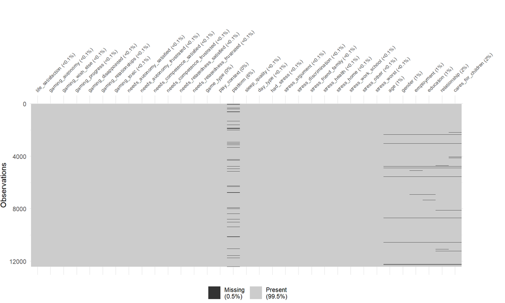

Missing values in the daily table. Black cells are missing.

```r
model_vars <- c("life_satisfaction", bangs, needs, day_preds, person_preds)

vis_miss(days[model_vars], warn_large_data = FALSE) +
  theme(plot.margin = margin(t = 25, r = 60), axis.text.x = element_text(size = 7))
```

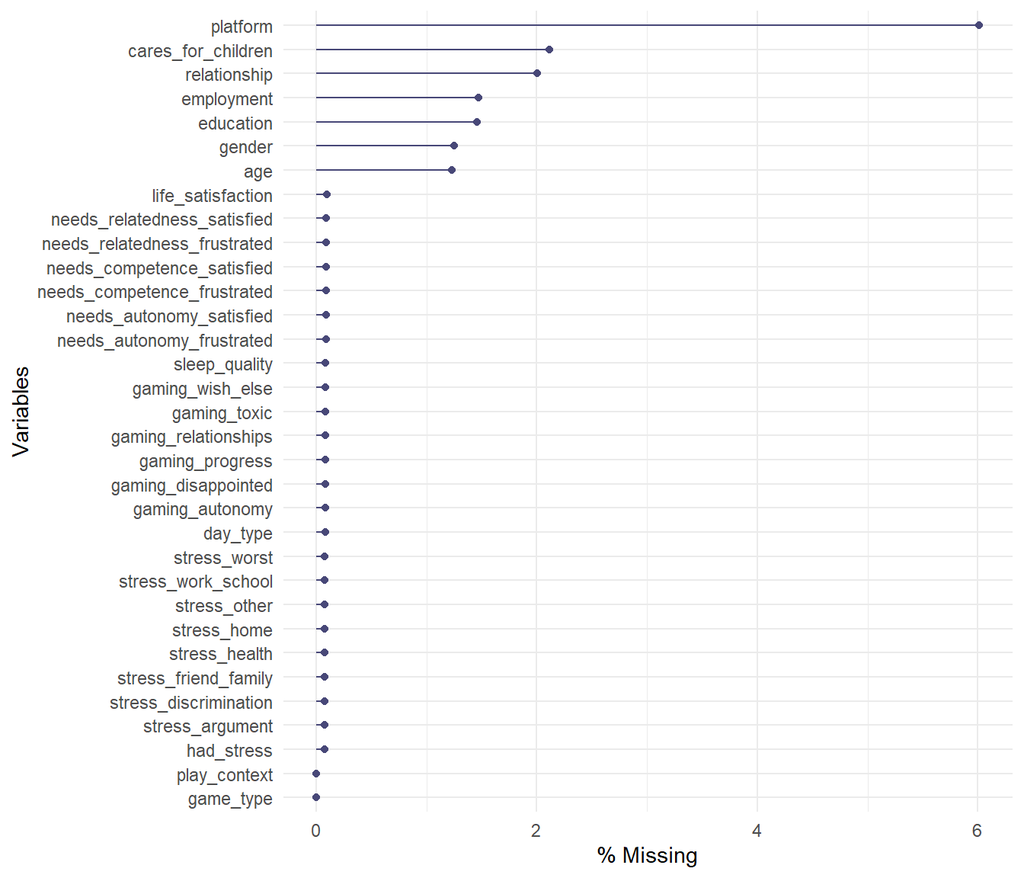

Percent missing for the target and each predictor.

```r
gg_miss_var(days[model_vars], show_pct = TRUE)
```

```r
miss_table <- data.frame(
  variable    = model_vars,
  n_missing   = colSums(is.na(days[model_vars])),
  pct_missing = round(100 * colMeans(is.na(days[model_vars])), 2),
  row.names   = NULL)
miss_table[order(-miss_table$pct_missing), ]
```

|  | variable | n_missing | pct_missing |
| --- | --- | --- | --- |
| 16 | platform | 747 | 6.01 |
| 33 | cares_for_children | 263 | 2.12 |
| 32 | relationship | 249 | 2.00 |
| 30 | employment | 183 | 1.47 |
| 31 | education | 181 | 1.46 |
| 29 | gender | 155 | 1.25 |
| 28 | age | 153 | 1.23 |
| 1 | life_satisfaction | 12 | 0.10 |
| 8 | needs_autonomy_satisfied | 11 | 0.09 |
| 9 | needs_autonomy_frustrated | 11 | 0.09 |
| 10 | needs_competence_satisfied | 11 | 0.09 |
| 11 | needs_competence_frustrated | 11 | 0.09 |
| 12 | needs_relatedness_satisfied | 11 | 0.09 |
| 13 | needs_relatedness_frustrated | 11 | 0.09 |
| 2 | gaming_autonomy | 10 | 0.08 |
| 3 | gaming_wish_else | 10 | 0.08 |
| 4 | gaming_progress | 10 | 0.08 |
| 5 | gaming_disappointed | 10 | 0.08 |
| 6 | gaming_relationships | 10 | 0.08 |
| 7 | gaming_toxic | 10 | 0.08 |
| 17 | sleep_quality | 10 | 0.08 |
| 18 | day_type | 10 | 0.08 |
| 19 | had_stress | 9 | 0.07 |
| 20 | stress_argument | 9 | 0.07 |
| 21 | stress_discrimination | 9 | 0.07 |
| 22 | stress_friend_family | 9 | 0.07 |
| 23 | stress_health | 9 | 0.07 |
| 24 | stress_home | 9 | 0.07 |
| 25 | stress_work_school | 9 | 0.07 |
| 26 | stress_other | 9 | 0.07 |
| 27 | stress_worst | 9 | 0.07 |
| 14 | game_type | 0 | 0.00 |
| 15 | play_context | 0 | 0.00 |

## Why are they missing?

**Platform** is the only daily variable with substantial missingness. It is missing almost entirely in the first months of the study, which suggests the question was added to the survey partway through:

```r
days %>%
  mutate(month = format(date, "%Y-%m")) %>%
  group_by(month) %>%
  summarise(days = n(),
            pct_platform_missing = round(100 * mean(is.na(platform)), 1),
            mean_life_sat = round(mean(life_satisfaction, na.rm = TRUE), 1))
```

| month | days | pct_platform_missing | mean_life_sat |
| --- | --- | --- | --- |
| 2024-10 | 198 | 100.0 | 62.8 |
| 2025-02 | 386 | 74.6 | 67.2 |
| 2025-03 | 956 | 10.0 | 65.8 |
| 2025-04 | 3512 | 2.6 | 65.1 |
| 2025-05 | 192 | 1.6 | 74.8 |
| 2025-06 | 2448 | 0.8 | 66.0 |
| 2025-07 | 4088 | 1.1 | 66.7 |
| 2025-08 | 639 | 0.8 | 67.2 |

```r
platform_target <- days %>%
  group_by(platform_missing = is.na(platform)) %>%
  summarise(days = n(),
            mean_life_sat = round(mean(life_satisfaction, na.rm = TRUE), 1))
platform_target
```

| platform_missing | days | mean_life_sat |
| --- | --- | --- |
| FALSE | 11672 | 66.1 |
| TRUE | 747 | 67.3 |

Missing platform depends on **when** someone took part, which is an observed fact, and not on their life satisfaction. Mean life satisfaction is 67.3 on days with platform missing and 66.1 on days with it recorded, so the gap does not mark a different kind of day. So it is most likely **MAR**, and KNN imputation inside the recipe fits that mechanism.

```r
# missing platform days, by whether the person gave a platform on other days
platform_gap <- days %>%
  group_by(id) %>%
  mutate(answered_other_days = any(!is.na(platform))) %>%
  ungroup() %>%
  filter(is.na(platform)) %>%
  count(answered_other_days)
platform_gap
```

| answered_other_days | n |
| --- | --- |
| FALSE | 266 |
| TRUE | 481 |

```r
# share of each person's answered days on their usual platform
# (people with 5 or more answered days)
usual_platform <- days %>%
  filter(!is.na(platform)) %>%
  group_by(id) %>%
  filter(n() >= 5) %>%
  summarise(share = max(table(platform)) / n())
round(mean(usual_platform$share), 2)
```

```
## [1] 0.77
```

**A limitation.** KNN fills each missing platform from similar days of other people. It does not look at the person’s own answers on other days. 481 of the 747 missing days belong to people who gave a platform on other days, and people played on their usual platform on 77% of their days. For those days, the person’s usual platform would likely be a better guess. We keep KNN, so that platform is imputed like every other predictor.

**The intake variables** are missing for two reasons:

- **The person has no intake record.** The most likely cause is a gap in linking the two surveys, which would be close to MCAR.
- **The person chose “Prefer not to say.”** This could be **MNAR**, because someone may decline a question because of their answer.

```r
# people in the daily table, by why each intake answer is missing
said_prefer_not <- function(answers) grepl("prefer not", tolower(answers))
in_person <- match(person$id, intake$pid)
care_prefer_not <- !is.na(intake$care_prefer_not_say[in_person]) &
                   intake$care_prefer_not_say[in_person] != ""

intake_missing <- data.frame(
  variable         = person_preds,
  no_intake_record = n_distinct(days$id[!days$id %in% intake$pid]),
  declined         = c(age          = 0,
                       gender       = sum(said_prefer_not(intake$gender[in_person])),
                       employment   = sum(said_prefer_not(intake$employment[in_person])),
                       education    = sum(said_prefer_not(intake$edu_level[in_person])),
                       relationship = sum(said_prefer_not(intake$marital_status[in_person])),
                       cares_for_children = sum(is.na(person$cares_for_children) & care_prefer_not)),
  row.names = NULL)
# an intake record, no answer, and no "Prefer not to say": the question was skipped
intake_missing$skipped <- colSums(is.na(person[person_preds])) - intake_missing$declined
stopifnot(intake_missing$skipped >= 0)
intake_missing
```

| variable | no_intake_record | declined | skipped |
| --- | --- | --- | --- |
| age | 46 | 0 | 0 |
| gender | 46 | 1 | 0 |
| employment | 46 | 1 | 1 |
| education | 46 | 3 | 0 |
| relationship | 46 | 9 | 0 |
| cares_for_children | 46 | 12 | 0 |

Most missing intake values come from the 46 people with no intake record. Only 1 to 12 people declined or skipped any one question, so the part that could be MNAR is small.

So the categorical intake variables get their own “Not reported” level instead of being imputed. Age and education are filled with the training median inside the recipe. Both are person-level facts, so every day of a person gets the same value, which KNN would not guarantee. For the people with no intake record, the “Not reported” levels already mark them as missing, so the median does not hide that. Only the 3 people who declined the education question are filled without such a marker.

```r
daily_vars <- c(bangs, needs, "sleep_quality", "day_type", "play_context",
                "had_stress", stress_types, "stress_worst")
max_daily_missing <- max(miss_table$n_missing[miss_table$variable %in% daily_vars])

# each block is missing all at once: 0 or 6 items on every day
table(bangs_missing = rowSums(is.na(days[bangs])))
```

```
## bangs_missing
##     0     6
## 12409    10
```

```r
table(needs_missing = rowSums(is.na(days[needs])))
```

```
## needs_missing
##     0     6
## 12408    11
```

**The daily items** (the BANGS items, the needs items, sleep, stress, type of day, play context) are each missing on 11 play days or fewer (0.1%). A day missing one BANGS item is missing all six, and the same holds for the needs items. These are unfinished surveys. Leaving a survey unfinished is unlikely to depend on the answers never given, so these are close to **MCAR**. They are imputed with KNN inside the recipe. KNN fills each column on its own, so on an imputed day the stress columns may not agree with each other (for example, `had_stress` “No” with an event type “Yes”). This can happen on at most 9 days.

**The worst stressor** would also be missing on a day the person said “Yes” but rated no event. 0 play days have that pattern, so it is missing only when the stress question itself is missing.

## Decisions

```r
c(missing_target = sum(is.na(days$life_satisfaction)))
```

```
## missing_target
##             12
```

```r
days <- days %>% filter(!is.na(life_satisfaction))

counts <- rbind(counts, data.frame(step = "Play days with a target",
                                   days = nrow(days), people = n_distinct(days$id)))
counts
```

| step | days | people |
| --- | --- | --- |
| All diary days | 16346 | 1284 |
| Play days | 12435 | 1171 |
| Play days with gaming answers | 12419 | 1170 |
| Play days with a target | 12407 | 1169 |

```r
# days complete on every predictor, counted before the "Not reported" levels
# are added (afterwards those days would look complete)
c(complete_days = sum(complete.cases(days[model_vars])))
```

```
## complete_days
##         11353
```

```r
not_reported <- function(x) {
  factor(ifelse(is.na(x), "Not reported", as.character(x)),
         levels = c(levels(x), "Not reported"))
}
for (v in c("gender", "employment", "relationship", "cares_for_children")) {
  days[[v]] <- not_reported(days[[v]])
}

sapply(days[c("gender", "employment", "relationship", "cares_for_children")], table)
```

```
## $gender
##
##                         Man                       Woman
##                        7922                        3491
## Non-binary / gender diverse                Not reported
##                         839                         155
##
## $employment
##
##                 Full-time Part-time / self-employed                   Student
##                      4599                      2241                      1830
##              Not employed              Not reported
##                      3554                       183
##
## $relationship
##
##                         Single                      Partnered
##                           8808                           3092
## Divorced / separated / widowed                   Not reported
##                            258                            249
##
## $cares_for_children
##
##           No          Yes Not reported
##        10710         1434          263
```

**Summary: how each kind of missing value is handled.**

| What is missing | Variables | Handling | Where and when | Why |
| --- | --- | --- | --- | --- |
| Question skipped by design | social boxes on non-play days; stress types and severity when `had_stress` is No | Recoded to “No” / “No event”, not imputed | Cleaning (Section 3) | The answer is known from the skip pattern |
| The play question | `played24hr` | Day dropped | Section 3 | Cannot tell whether it is a play day; nearly all are empty surveys |
| Every gaming answer on a play day | title, social boxes, platform, and all BANGS items | Day dropped | Section 3 | The day says nothing about the session |
| The target | `life_satisfaction` | Day dropped | Section 4, before the split | Nothing to train on or score |
| An unreadable or conflicting game title | `game_type` | “Unknown” level | Section 3 | A real category of answer, not a gap |
| A categorical intake answer | gender, employment, relationship, cares for children | “Not reported” level | Section 4, before the split | Declining may depend on the answer (MNAR); the level keeps that information |
| A numeric intake answer | age, education | Training median | Model recipes (Section 8), relearned in each fold | A fact about the person, so every day of a person gets the same value |
| A daily answer, in the models | BANGS items, needs items (set A), sleep, type of day, platform, `had_stress`, stress types, `stress_worst` | KNN, 5 neighbors, from the other predictors (never the target) | Model recipes (Section 8), relearned in each fold | Unfinished surveys (MCAR) and the late-added platform question (MAR) |
| A BANGS or needs block, before clustering and PCA | the 6 BANGS items, the 6 needs items | Training median | Block recipes (Section 6), learned once on the training days | The blocks must be filled first, and a day missing one item misses all six, so KNN has nothing to match on |
| Cluster and component scores | `play_day_type`, `need_satisfaction`, `need_frustration` | Nothing missing | Section 6 | Built from the already-filled blocks |

**The life satisfaction slider.** The values 0, 50, and 100 are kept as real answers:

```r
summary(days$life_satisfaction)
```

```
##    Min. 1st Qu.  Median    Mean 3rd Qu.    Max.
##    0.00   51.00   70.00   66.14   83.00  100.00
```

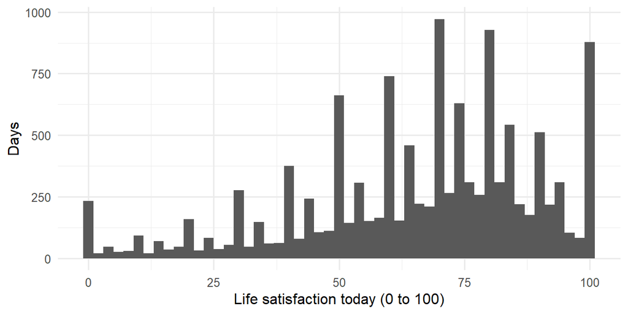

Life satisfaction on play days.

```r
ggplot(days, aes(life_satisfaction)) +
  geom_histogram(binwidth = 2) +
  labs(x = "Life satisfaction today (0 to 100)", y = "Days")
```

## The variable table

```r
pm <- function(v) paste0(miss_table$pct_missing[miss_table$variable == v], "%")
bangs_stem <- "\"In my most recent session of [game]...\" "
needs_stem <- "\"Today...\" "
agree7 <- " (1 to 7, strongly disagree to strongly agree)"
stress_stem <- "\"What kind of stressful event(s) occurred?\" Checkbox: "

var_table <- tibble::tribble(
  ~variable, ~source, ~item, ~treatment, ~daily_summary, ~missing,
  "life_satisfaction (target)", "daily", "\"I was satisfied with my life today.\" 0 to 100 slider", "Continuous target", "as rated (same day)", paste0(pm("life_satisfaction"), "; rows dropped"),
  "gaming_autonomy", "daily, play days", paste0(bangs_stem, "\"I could play in the way I wanted.\"", agree7), "Numeric; clustering block", "as rated, most recent session", paste0(pm("gaming_autonomy"), "; KNN"),
  "gaming_wish_else", "daily, play days", paste0(bangs_stem, "\"I often found myself wishing I could do something else.\"", agree7), "Numeric; clustering block", "as rated, most recent session", paste0(pm("gaming_wish_else"), "; KNN"),
  "gaming_progress", "daily, play days", paste0(bangs_stem, "\"I felt that I made progress while playing.\"", agree7), "Numeric; clustering block", "as rated, most recent session", paste0(pm("gaming_progress"), "; KNN"),
  "gaming_disappointed", "daily, play days", paste0(bangs_stem, "\"I felt disappointed with my performance.\"", agree7), "Numeric; clustering block", "as rated, most recent session", paste0(pm("gaming_disappointed"), "; KNN"),
  "gaming_relationships", "daily, play days", paste0(bangs_stem, "\"I felt I formed relationships with other players and/or characters.\"", agree7), "Numeric; clustering block", "as rated, most recent session", paste0(pm("gaming_relationships"), "; KNN"),
  "gaming_toxic", "daily, play days", paste0(bangs_stem, "\"Interactions with other players and/or characters felt toxic to me.\"", agree7), "Numeric; clustering block", "as rated, most recent session", paste0(pm("gaming_toxic"), "; KNN"),
  "needs_autonomy_satisfied", "daily", paste0(needs_stem, "\"...I was able to do things that I really want and value in life.\"", agree7), "Numeric; PCA block", "as rated (same day)", paste0(pm("needs_autonomy_satisfied"), "; KNN"),
  "needs_autonomy_frustrated", "daily", paste0(needs_stem, "\"...I felt forced to do many things I wouldn't choose to do.\"", agree7), "Numeric; PCA block", "as rated (same day)", paste0(pm("needs_autonomy_frustrated"), "; KNN"),
  "needs_competence_satisfied", "daily", paste0(needs_stem, "\"...I could do things well and achieve my goals.\"", agree7), "Numeric; PCA block", "as rated (same day)", paste0(pm("needs_competence_satisfied"), "; KNN"),
  "needs_competence_frustrated", "daily", paste0(needs_stem, "\"...I felt insecure about my abilities.\"", agree7), "Numeric; PCA block", "as rated (same day)", paste0(pm("needs_competence_frustrated"), "; KNN"),
  "needs_relatedness_satisfied", "daily", paste0(needs_stem, "\"...I felt close and connected with other people whom I care about and who care about me.\"", agree7), "Numeric; PCA block", "as rated (same day)", paste0(pm("needs_relatedness_satisfied"), "; KNN"),
  "needs_relatedness_frustrated", "daily", paste0(needs_stem, "\"...I felt excluded from the group I want to belong to.\"", agree7), "Numeric; PCA block", "as rated (same day)", paste0(pm("needs_relatedness_frustrated"), "; KNN"),
  "game_type", "daily (engineered)", "Type of the most recent game, coded from the typed title and the day's play context; every game on a solo-only day is single-player (the person's answer)","5-level factor: single-player, non-competitive, individual competition, team competition, unknown", "most recent session", "0%",
  "play_context", "daily (engineered)", "\"While gaming today, what kind of social interaction did you take part in?\" Four checkboxes", "4-level factor: solo only, friends only, friends + strangers, strangers only", "whole day", paste0(pm("play_context"), " (days with no gaming answers dropped)"),
  "platform", "daily", "\"Which platform did this session take place on?\"", "6-level factor (iOS + Android = Mobile; typed answers = Other)", "most recent session", paste0(pm("platform"), "; KNN"),
  "sleep_quality", "daily", "\"How do you rate the quality of your sleep?\" 1 = very poor to 5 = very good", "Numeric", "last night (same-day survey)", paste0(pm("sleep_quality"), "; KNN"),
  "day_type", "daily", "\"Which best describes today for you?\"", "5-level factor (holiday and vacation combined)", "as reported", paste0(pm("day_type"), "; KNN"),
  "had_stress", "daily", "\"Did anything happen to you in the last 24 hours that most people would consider stressful?\"", "No/Yes factor", "last 24 hours", paste0(pm("had_stress"), "; KNN"),
  "stress_argument ... stress_other (7)", "daily (engineered)", paste0(stress_stem, "argument, discrimination, friend or relative, health, home, work or school, other"), "No/Yes factors; No when had_stress = No", "last 24 hours", paste0("up to ", pm("stress_argument"), "; KNN"),
  "stress_worst", "daily (engineered)", "\"How stressful was this event?\" asked for each event, 1 = not at all to 4 = very", "Ordered factor: None < Not very < Somewhat < Very (highest rating; the 2 \"Not at all\" days coded Not very)", "maximum over the day's events", paste0(pm("stress_worst"), "; KNN"),
  "age", "intake", "\"What is your age in years?\"", "Numeric", "person-level", paste0(pm("age"), "; median"),
  "gender", "intake", "\"What gender do you identify with?\"", "Factor: man, woman, non-binary / gender diverse, not reported", "person-level", paste0(pm("gender"), "; \"Not reported\" level"),
  "employment", "intake", "\"What best describes your employment status over the last three months?\"", "Factor: full-time, part-time / self-employed, student, not employed, not reported", "person-level", paste0(pm("employment"), "; \"Not reported\" level"),
  "education", "intake", "\"What is the highest level of education you have completed?\"", "Numeric 1 to 6", "person-level", paste0(pm("education"), "; median"),
  "relationship", "intake", "\"What is your current marital status?\"", "Factor: single, partnered, divorced / separated / widowed, not reported", "person-level", paste0(pm("relationship"), "; \"Not reported\" level"),
  "cares_for_children", "intake", "\"Do you have any caregiving responsibilities?\" Checkbox: I care for children", "Factor: no, yes, not reported", "person-level", paste0(pm("cares_for_children"), "; \"Not reported\" level"),
  "need_satisfaction, need_frustration (set B)", "engineered", "Varimax-rotated principal component scores of the six needs items (Section 6b)", "Numeric; weights fit on training days, applied to test days", "same day", "0% (block imputed first)",
  "play_day_type (set B)", "engineered", "K-means cluster (K = 3) of the six BANGS items (Section 6a): smooth solo, connected, frustrating play day", "Factor; centroids fit on training days, test days get the nearest centroid", "most recent session", "0% (block imputed first)",
  "affective_valence", "removed", "\"How are you feeling right now?\"", "Removed: the target in another form", "-", "-",
  "id, day, date", "removed", "Participant ID, study day, timestamp", "Removed (id used only to split by person)", "-", "-"
)

knitr::kable(var_table)
```

| variable | source | item | treatment | daily_summary | missing |
| --- | --- | --- | --- | --- | --- |
| life_satisfaction (target) | daily | “I was satisfied with my life today.” 0 to 100 slider | Continuous target | as rated (same day) | 0.1%; rows dropped |
| gaming_autonomy | daily, play days | “In my most recent session of [game]…” “I could play in the way I wanted.” (1 to 7, strongly disagree to strongly agree) | Numeric; clustering block | as rated, most recent session | 0.08%; KNN |
| gaming_wish_else | daily, play days | “In my most recent session of [game]…” “I often found myself wishing I could do something else.” (1 to 7, strongly disagree to strongly agree) | Numeric; clustering block | as rated, most recent session | 0.08%; KNN |
| gaming_progress | daily, play days | “In my most recent session of [game]…” “I felt that I made progress while playing.” (1 to 7, strongly disagree to strongly agree) | Numeric; clustering block | as rated, most recent session | 0.08%; KNN |
| gaming_disappointed | daily, play days | “In my most recent session of [game]…” “I felt disappointed with my performance.” (1 to 7, strongly disagree to strongly agree) | Numeric; clustering block | as rated, most recent session | 0.08%; KNN |
| gaming_relationships | daily, play days | “In my most recent session of [game]…” “I felt I formed relationships with other players and/or characters.” (1 to 7, strongly disagree to strongly agree) | Numeric; clustering block | as rated, most recent session | 0.08%; KNN |
| gaming_toxic | daily, play days | “In my most recent session of [game]…” “Interactions with other players and/or characters felt toxic to me.” (1 to 7, strongly disagree to strongly agree) | Numeric; clustering block | as rated, most recent session | 0.08%; KNN |
| needs_autonomy_satisfied | daily | “Today…” “…I was able to do things that I really want and value in life.” (1 to 7, strongly disagree to strongly agree) | Numeric; PCA block | as rated (same day) | 0.09%; KNN |
| needs_autonomy_frustrated | daily | “Today…” “…I felt forced to do many things I wouldn’t choose to do.” (1 to 7, strongly disagree to strongly agree) | Numeric; PCA block | as rated (same day) | 0.09%; KNN |
| needs_competence_satisfied | daily | “Today…” “…I could do things well and achieve my goals.” (1 to 7, strongly disagree to strongly agree) | Numeric; PCA block | as rated (same day) | 0.09%; KNN |
| needs_competence_frustrated | daily | “Today…” “…I felt insecure about my abilities.” (1 to 7, strongly disagree to strongly agree) | Numeric; PCA block | as rated (same day) | 0.09%; KNN |
| needs_relatedness_satisfied | daily | “Today…” “…I felt close and connected with other people whom I care about and who care about me.” (1 to 7, strongly disagree to strongly agree) | Numeric; PCA block | as rated (same day) | 0.09%; KNN |
| needs_relatedness_frustrated | daily | “Today…” “…I felt excluded from the group I want to belong to.” (1 to 7, strongly disagree to strongly agree) | Numeric; PCA block | as rated (same day) | 0.09%; KNN |
| game_type | daily (engineered) | Type of the most recent game, coded from the typed title and the day’s play context; every game on a solo-only day is single-player (the person’s answer) | 5-level factor: single-player, non-competitive, individual competition, team competition, unknown | most recent session | 0% |
| play_context | daily (engineered) | “While gaming today, what kind of social interaction did you take part in?” Four checkboxes | 4-level factor: solo only, friends only, friends + strangers, strangers only | whole day | 0% (days with no gaming answers dropped) |
| platform | daily | “Which platform did this session take place on?” | 6-level factor (iOS + Android = Mobile; typed answers = Other) | most recent session | 6.01%; KNN |
| sleep_quality | daily | “How do you rate the quality of your sleep?” 1 = very poor to 5 = very good | Numeric | last night (same-day survey) | 0.08%; KNN |
| day_type | daily | “Which best describes today for you?” | 5-level factor (holiday and vacation combined) | as reported | 0.08%; KNN |
| had_stress | daily | “Did anything happen to you in the last 24 hours that most people would consider stressful?” | No/Yes factor | last 24 hours | 0.07%; KNN |
| stress_argument … stress_other (7) | daily (engineered) | “What kind of stressful event(s) occurred?” Checkbox: argument, discrimination, friend or relative, health, home, work or school, other | No/Yes factors; No when had_stress = No | last 24 hours | up to 0.07%; KNN |
| stress_worst | daily (engineered) | “How stressful was this event?” asked for each event, 1 = not at all to 4 = very | Ordered factor: None < Not very < Somewhat < Very (highest rating; the 2 “Not at all” days coded Not very) | maximum over the day’s events | 0.07%; KNN |
| age | intake | “What is your age in years?” | Numeric | person-level | 1.23%; median |
| gender | intake | “What gender do you identify with?” | Factor: man, woman, non-binary / gender diverse, not reported | person-level | 1.25%; “Not reported” level |
| employment | intake | “What best describes your employment status over the last three months?” | Factor: full-time, part-time / self-employed, student, not employed, not reported | person-level | 1.47%; “Not reported” level |
| education | intake | “What is the highest level of education you have completed?” | Numeric 1 to 6 | person-level | 1.46%; median |
| relationship | intake | “What is your current marital status?” | Factor: single, partnered, divorced / separated / widowed, not reported | person-level | 2%; “Not reported” level |
| cares_for_children | intake | “Do you have any caregiving responsibilities?” Checkbox: I care for children | Factor: no, yes, not reported | person-level | 2.12%; “Not reported” level |
| need_satisfaction, need_frustration (set B) | engineered | Varimax-rotated principal component scores of the six needs items (Section 6b) | Numeric; weights fit on training days, applied to test days | same day | 0% (block imputed first) |
| play_day_type (set B) | engineered | K-means cluster (K = 3) of the six BANGS items (Section 6a): smooth solo, connected, frustrating play day | Factor; centroids fit on training days, test days get the nearest centroid | most recent session | 0% (block imputed first) |
| affective_valence | removed | “How are you feeling right now?” | Removed: the target in another form | - | - |
| id, day, date | removed | Participant ID, study day, timestamp | Removed (id used only to split by person) | - | - |

# 5. Split by Person

```r
days_per_person <- table(days$id)
summary(as.vector(days_per_person))
```

```
##    Min. 1st Qu.  Median    Mean 3rd Qu.    Max.
##    1.00    2.00    7.00   10.61   19.00   30.00
```

```r
# share of life satisfaction variance between people (one-way ANOVA ICC)
aov_fit <- anova(lm(life_satisfaction ~ factor(id), data = days))
ms_b  <- aov_fit["factor(id)", "Mean Sq"]
ms_w  <- aov_fit["Residuals", "Mean Sq"]
k_avg <- (nrow(days) - sum(days_per_person^2) / nrow(days)) / (length(days_per_person) - 1)
icc   <- (ms_b - ms_w) / (ms_b + (k_avg - 1) * ms_w)
round(icc, 2)
```

```
## [1] 0.73
```

About 73% of the variation in daily life satisfaction lies between people. The intake predictors are also constant within a person. A split over days would put most people in both sets. A model could then learn each person’s usual level from their training days, partly through the intake variables, and score well on the test set without predicting anything new.

So we depart from the handout’s day-level `initial_split()`, as the proposal says, and split by **person**:

- `group_initial_split()` puts 70% of people in the training set and 30% in the test set, with seed 559.
- The split is stratified on each person’s mean life satisfaction (quartiles). This is the person-level version of “stratified on the target.”
- Cross-validation also holds out whole people.

The test set therefore checks how well the model does for **new players**.

```r
person_ls <- tapply(days$life_satisfaction, days$id, mean)
days$ls_strata <- cut(person_ls[as.character(days$id)],
                      breaks = quantile(person_ls, probs = seq(0, 1, 0.25)),
                      include.lowest = TRUE, labels = FALSE)

set.seed(559)
split <- group_initial_split(days, group = id, prop = 0.7, strata = ls_strata)
train <- training(split)
test  <- testing(split)

split_sizes <- data.frame(
  set    = c("training", "test"),
  days   = c(nrow(train), nrow(test)),
  people = c(n_distinct(train$id), n_distinct(test$id)),
  mean_life_sat = round(c(mean(train$life_satisfaction), mean(test$life_satisfaction)), 1),
  sd_life_sat   = round(c(sd(train$life_satisfaction), sd(test$life_satisfaction)), 1))
split_sizes
```

| set | days | people | mean_life_sat | sd_life_sat |
| --- | --- | --- | --- | --- |
| training | 8677 | 814 | 65.7 | 24.2 |
| test | 3730 | 355 | 67.2 | 22.4 |

```r
# no person is in both sets
length(intersect(train$id, test$id))
```

```
## [1] 0
```

From here on, `test` is used only to receive the cluster labels and component scores learned on `train`, until the final evaluation in Section 9.

```r
n_folds <- 10

set.seed(559)
folds <- groupKFold(train$id, k = n_folds)

# The folds are fit in parallel (Section 8), so set.seed() alone would not
# fix the random parts of each fit (the forests' bootstrap samples).
# caret takes one seed per fold and tuning value, plus one for the final fit.
# 1000 per fold covers every tuning grid used here.
fold_seeds <- c(lapply(seq_len(n_folds), function(i) sample.int(1e6, 1000)),
                list(sample.int(1e6, 1)))
ctrl  <- trainControl(method = "cv", number = n_folds, index = folds,
                      savePredictions = "final", seeds = fold_seeds)

# people and days held out in each fold
sapply(folds, function(rows) c(people_out = n_distinct(train$id[-rows]),
                               days_out   = nrow(train) - length(rows)))
```

```
##            Fold01 Fold02 Fold03 Fold04 Fold05 Fold06 Fold07 Fold08 Fold09
## people_out     72     82     98     76     86     81     71    100     83
## days_out      777    980    938    870   1037    704    725    985    912
##            Fold10
## people_out     65
## days_out      749
```

The handout asks us to state the number of folds. We use **10 grouped folds**, the number the handout asks for in the report (“use ten in your report”). Each fold holds out about a tenth of the training people. All models (Section 8) get these same folds through `index`.

# 6. Unsupervised Analysis

Everything in this section is fit on the **training days only**. Test days get their cluster labels and component scores from the training fit. Neither block contains the target. Both are imputed (training medians) and centered and scaled (training means and SDs) in a recipe first, because K-means and PCA work from distances and cannot take missing values. Both blocks are 1 to 7 numeric items, so there are no categorical items to encode.

**Why the blocks are filled with the median here, but with KNN in the models.**

- **The blocks must be filled first.** K-means and PCA cannot run with missing values, and they are run once, here, before any model.
- **KNN has nothing to work with inside a block.** KNN fills a missing answer by finding days with similar answers to the other questions. But a day missing one item of a block is missing all six (Section 4), so within the block there are no other answers to compare. The training median is the simple fill that is left.
- **The models are different.** Their recipes (Section 8) see every predictor, so KNN has plenty to match on there, and caret relearns it in each fold.
- **No leakage.** The medians come from the training days only and never use the target.
- **Small cost.** Every filled day gets the same values: the same play-day type and the same two component scores (shown below). Only 1 training and 2 test days are filled for the BANGS items, and 3 training and 0 test days for the needs items. The effect on the structure and on set B is negligible.

## 6a. Clustering: types of play days

The handout asks for clusters that are types of days. Each play day is clustered on its six BANGS answers, which describe how that day’s most recent gaming session went, so each type is a kind of play day defined by its gaming. Days without play have no BANGS answers and no type.

### The block

```r
rec_bangs <- recipe(~ ., data = train[bangs]) %>%
  step_impute_median(all_numeric_predictors()) %>%
  step_normalize(all_numeric_predictors()) %>%
  prep()

train_bangs <- bake(rec_bangs, new_data = train)
test_bangs  <- bake(rec_bangs, new_data = test)

round(cor(train_bangs), 2)
```

```
##                      gaming_autonomy gaming_wish_else gaming_progress
## gaming_autonomy                 1.00            -0.41            0.49
## gaming_wish_else               -0.41             1.00           -0.35
## gaming_progress                 0.49            -0.35            1.00
## gaming_disappointed            -0.45             0.41           -0.42
## gaming_relationships            0.19            -0.13            0.25
## gaming_toxic                   -0.26             0.33           -0.23
##                      gaming_disappointed gaming_relationships gaming_toxic
## gaming_autonomy                    -0.45                 0.19        -0.26
## gaming_wish_else                    0.41                -0.13         0.33
## gaming_progress                    -0.42                 0.25        -0.23
## gaming_disappointed                 1.00                -0.09         0.37
## gaming_relationships               -0.09                 1.00         0.05
## gaming_toxic                        0.37                 0.05         1.00
```

Autonomy and progress go together, and wishing to do something else, disappointment, and toxicity go together. Forming relationships is nearly independent of the rest.

### How many types?

We use two criteria: the **elbow** in the total within-cluster sum of squares, and the **average silhouette width**. Each K-means fit uses 25 random starts. The silhouette is computed from the distances between all training days.

```r
k_range <- 1:8

km_fits <- lapply(k_range, function(k) {
  set.seed(559)
  kmeans(train_bangs, centers = k, nstart = 25, iter.max = 50)
})

bangs_dist <- dist(train_bangs)
k_choice <- data.frame(
  K   = k_range,
  wss = sapply(km_fits, `[[`, "tot.withinss"),
  silhouette = c(NA, sapply(km_fits[-1], function(km)
    mean(silhouette(km$cluster, bangs_dist)[, 3]))))
rm(bangs_dist)

k_choice %>% mutate(share_of_k1 = round(wss / wss[1], 3),
                    silhouette  = round(silhouette, 3))
```

| K | wss | silhouette | share_of_k1 |
| --- | --- | --- | --- |
| 1 | 52056.00 | NA | 1.000 |
| 2 | 37276.05 | 0.292 | 0.716 |
| 3 | 32298.41 | 0.218 | 0.620 |
| 4 | 29119.64 | 0.211 | 0.559 |
| 5 | 26640.52 | 0.210 | 0.512 |
| 6 | 24769.27 | 0.210 | 0.476 |
| 7 | 23352.40 | 0.210 | 0.449 |
| 8 | 22107.37 | 0.199 | 0.425 |

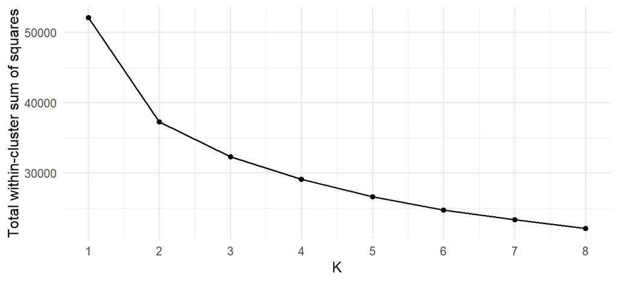

Elbow plot: total within-cluster sum of squares by K (training days).

```r
ggplot(k_choice, aes(K, wss)) + geom_point() + geom_line() +
  scale_x_continuous(breaks = k_range) +
  labs(y = "Total within-cluster sum of squares")
```

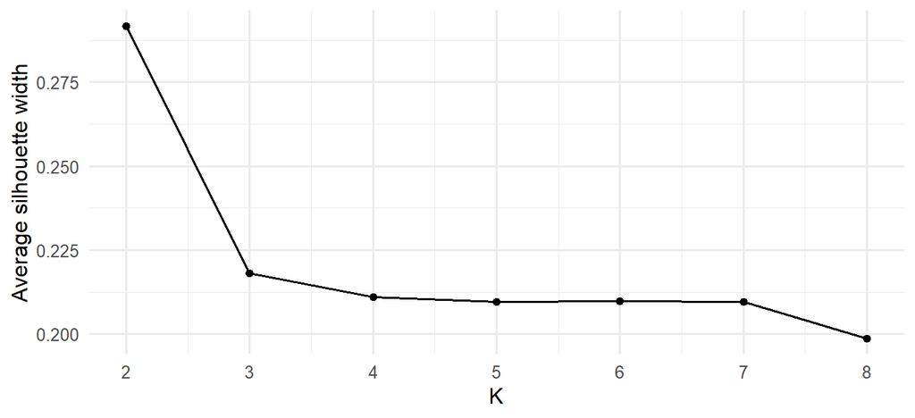

Average silhouette width by K (training days).

```r
ggplot(filter(k_choice, K > 1), aes(K, silhouette)) + geom_point() + geom_line() +
  scale_x_continuous(breaks = k_range) +
  labs(y = "Average silhouette width")
```

**Choosing K.** Both criteria point to the same region, and neither gives a sharp answer:

- The silhouette is highest at K = 2 (0.29). It is 0.22 at K = 3 and stays near that value for every larger K. Silhouettes around 0.2 to 0.3 mean the types overlap. Play days vary continuously and do not fall into separate groups.
- The elbow bends at K = 2 to 3. Going from 1 to 2 clusters removes 28% of the within-cluster variation, 2 to 3 removes another 10%, and later steps remove less.

We keep **K = 3**:

- **Against K = 2.** K = 2 only separates good play days from bad ones. K = 3 splits the good days by whether the person formed relationships while playing. That is the one BANGS item the others do not capture (the correlation table above), and the split matters for the target (below).
- **Against K = 4.** K = 4 is a finer cut. It splits the frustrating days further, but its silhouette is no better and the solution is less stable.
- Section 8 checks K = 2 and K = 4 against K = 3 on the training folds: profiles, stability, and prediction.

```r
k_final <- 3
km <- km_fits[[k_final]]

km$size
```

```
## [1] 3986 2654 2037
```

```r
round(km$betweenss / km$totss, 2)   # share of variation between the clusters
```

```
## [1] 0.38
```

### Profiles and names

The centroids are in z scores. The profile table gives the item means in the original 1 to 7 units, the cluster sizes, and who the person played with.

```r
cluster_profile <- function(labels) {
  train[bangs] %>%
    mutate(cluster = labels) %>%
    group_by(cluster) %>%
    summarise(across(everything(), ~ round(mean(.x, na.rm = TRUE), 1)),
              days = n(), .groups = "drop") %>%
    as.data.frame()
}

cluster_profile(km_fits[[2]]$cluster)   # K = 2, for comparison
```

| cluster | gaming_autonomy | gaming_wish_else | gaming_progress | gaming_disappointed | gaming_relationships | gaming_toxic | days |
| --- | --- | --- | --- | --- | --- | --- | --- |
| 1 | 6.2 | 1.7 | 6.0 | 1.6 | 4.0 | 1.5 | 5600 |
| 2 | 4.6 | 3.6 | 4.3 | 3.5 | 3.3 | 3.0 | 3077 |

```r
cluster_profile(km$cluster)
```

| cluster | gaming_autonomy | gaming_wish_else | gaming_progress | gaming_disappointed | gaming_relationships | gaming_toxic | days |
| --- | --- | --- | --- | --- | --- | --- | --- |
| 1 | 6.2 | 1.7 | 6.0 | 1.7 | 5.1 | 1.7 | 3986 |
| 2 | 4.6 | 3.7 | 4.3 | 3.7 | 3.4 | 3.2 | 2654 |
| 3 | 6.0 | 1.9 | 5.6 | 1.7 | 1.5 | 1.3 | 2037 |

The names are assigned by rule, so they stay attached to the right cluster even if the cluster numbers change:

- the cluster with the highest relationships mean is the **connected play day**;
- of the other two, the one with lower autonomy is the **frustrating play day**;
- the last is the **smooth solo play day**.

```r
prof <- cluster_profile(km$cluster)
connected   <- prof$cluster[which.max(prof$gaming_relationships)]
others      <- setdiff(prof$cluster, connected)
frustrating <- others[which.min(prof$gaming_autonomy[match(others, prof$cluster)])]
smooth      <- setdiff(others, c(frustrating))

cluster_names <- character(k_final)
cluster_names[connected]   <- "Connected play day"
cluster_names[frustrating] <- "Frustrating play day"
cluster_names[smooth]      <- "Smooth solo play day"

type_levels <- c("Smooth solo play day", "Connected play day", "Frustrating play day")
train$play_day_type <- factor(cluster_names[km$cluster], levels = type_levels)

table(train$play_day_type)
```

```
##
## Smooth solo play day   Connected play day Frustrating play day
##                 2037                 3986                 2654
```

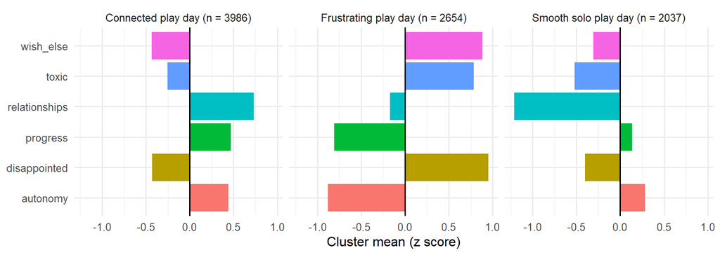

Cluster centroids on the six BANGS items (z scores, training days).

```r
as.data.frame(km$centers) %>%
  mutate(cluster = paste0(cluster_names, " (n = ", km$size, ")")) %>%
  pivot_longer(-cluster, names_to = "item", values_to = "z") %>%
  mutate(item = sub("gaming_", "", item)) %>%
  ggplot(aes(item, z, fill = item)) +
  geom_col() + geom_hline(yintercept = 0) +
  facet_wrap(~ cluster) + coord_flip() +
  theme(legend.position = "none") +
  labs(x = NULL, y = "Cluster mean (z score)")
```

Who people played with, and what they played, in each type (row percentages, training days):

```r
round(100 * prop.table(table(train$play_day_type, train$play_context), 1))
```

```
##
##                        Solo only Friends only Friends + strangers
##   Smooth solo play day        61           11                   6
##   Connected play day          41           33                  12
##   Frustrating play day        36           27                  12
##
##                        Strangers only
##   Smooth solo play day             23
##   Connected play day               13
##   Frustrating play day             26
```

```r
round(100 * prop.table(table(train$play_day_type, train$game_type), 1))
```

```
##
##                        Single-player Non-competitive Individual competition
##   Smooth solo play day            68              14                      8
##   Connected play day              48              27                      8
##   Frustrating play day            41              17                     10
##
##                        Team competition Unknown
##   Smooth solo play day                9       0
##   Connected play day                 17       0
##   Frustrating play day               31       0
```

What the three types are:

- **Smooth solo play day.** The person played the way they wanted and made progress. There was little disappointment and almost no toxicity, but no relationships were formed. Most of these days were solo, single-player play.
- **Connected play day.** The gaming went just as smoothly, and the person also formed relationships with other players or characters. These days are split between solo and friends play. The item asks about players *or characters*, so a story game can count.
- **Frustrating play day.** Autonomy and progress were lower, and wishing to do something else, disappointment, and toxicity were higher. Team competition and strangers-only play are more common than on the other types of day.

Compared with the proposal: the expected day with a “satisfying solo session” appears. The days with a “toxic competitive” or “low improvement” session appear together as one frustrating type, which leans toward competitive play but is not defined by it. Toxicity is only moderate even there (mean 3.2 on the 1 to 7 scale, below the midpoint). At K = 4 the two separate (Section 8), but the extra split is less stable and is not supported by the silhouette.

### Life satisfaction across the types (training days)

```r
train %>%
  group_by(play_day_type) %>%
  summarise(days = n(),
            mean_life_sat = round(mean(life_satisfaction), 1),
            sd_life_sat   = round(sd(life_satisfaction), 1),
            pct_stress    = round(100 * mean(had_stress == "Yes", na.rm = TRUE), 1),
            mean_sleep    = round(mean(sleep_quality, na.rm = TRUE), 2)) %>%
  as.data.frame()
```

| play_day_type | days | mean_life_sat | sd_life_sat | pct_stress | mean_sleep |
| --- | --- | --- | --- | --- | --- |
| Smooth solo play day | 2037 | 65.3 | 25.2 | 13.3 | 3.27 |
| Connected play day | 3986 | 72.7 | 21.3 | 11.3 | 3.45 |
| Frustrating play day | 2654 | 55.5 | 23.9 | 18.2 | 3.01 |

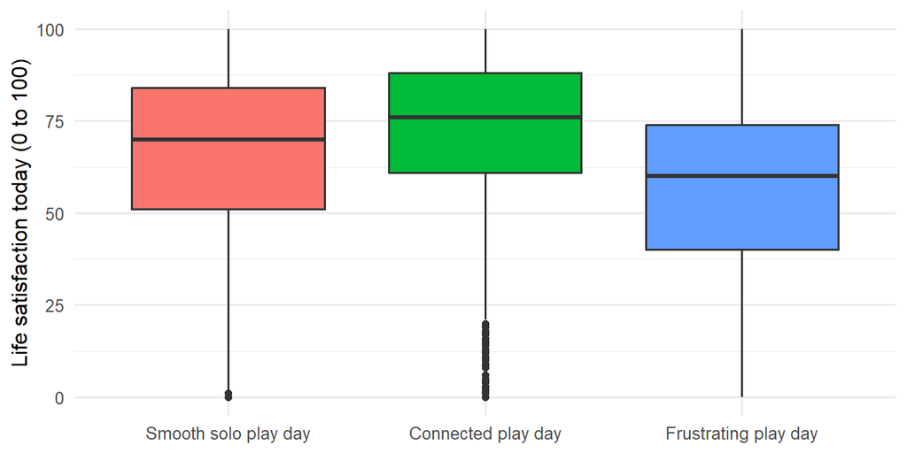

Life satisfaction by type of play day (training days).

```r
ggplot(train, aes(play_day_type, life_satisfaction, fill = play_day_type)) +
  geom_boxplot() +
  theme(legend.position = "none") +
  labs(x = NULL, y = "Life satisfaction today (0 to 100)")
```

The type of play day is clearly related to life satisfaction that day, even though no BANGS item asks about life. Frustrating play days are the lowest and connected play days the highest. The spread within each type is wide, and these are same-day associations. A bad day may make the gaming feel worse as much as the other way around.

### Test days

`kmeans()` has no `predict()` method. A test day joins the training centroid it is closest to, in the training-standardized units.

```r
nearest_centroid <- function(x, centers) {
  x  <- as.matrix(x)
  d2 <- sapply(seq_len(nrow(centers)), function(k)
    rowSums((x - matrix(centers[k, ], nrow(x), ncol(x), byrow = TRUE))^2))
  max.col(-d2, ties.method = "first")
}

test$play_day_type <- factor(cluster_names[nearest_centroid(test_bangs, km$centers)],
                            levels = type_levels)

# the rule gives the training days their own clusters back
mean(nearest_centroid(train_bangs, km$centers) == km$cluster)
```

```
## [1] 1
```

```r
round(rbind(train = prop.table(table(train$play_day_type)),
            test  = prop.table(table(test$play_day_type))), 2)
```

```
##       Smooth solo play day Connected play day Frustrating play day
## train                 0.23               0.46                 0.31
## test                  0.23               0.46                 0.31
```

```r
# days with no BANGS answers were filled with the training medians, so they
# all get the play-day type nearest the median profile
table(filled_day_type = c(
  as.character(train$play_day_type[rowSums(is.na(train[bangs])) > 0]),
  as.character(test$play_day_type[rowSums(is.na(test[bangs])) > 0])))
```

```
## filled_day_type
## Connected play day
##                  3
```

## 6b. Principal components: dimensions of a day’s needs

### The block

```r
rec_needs <- recipe(~ ., data = train[needs]) %>%
  step_impute_median(all_numeric_predictors()) %>%
  step_normalize(all_numeric_predictors()) %>%
  prep()

train_needs <- bake(rec_needs, new_data = train)
test_needs  <- bake(rec_needs, new_data = test)

round(cor(train_needs), 2)
```

```
##                              needs_autonomy_satisfied needs_autonomy_frustrated
## needs_autonomy_satisfied                         1.00                     -0.43
## needs_autonomy_frustrated                       -0.43                      1.00
## needs_competence_satisfied                       0.75                     -0.40
## needs_competence_frustrated                     -0.53                      0.47
## needs_relatedness_satisfied                      0.60                     -0.36
## needs_relatedness_frustrated                    -0.44                      0.46
##                              needs_competence_satisfied
## needs_autonomy_satisfied                           0.75
## needs_autonomy_frustrated                         -0.40
## needs_competence_satisfied                         1.00
## needs_competence_frustrated                       -0.59
## needs_relatedness_satisfied                        0.57
## needs_relatedness_frustrated                      -0.44
##                              needs_competence_frustrated
## needs_autonomy_satisfied                           -0.53
## needs_autonomy_frustrated                           0.47
## needs_competence_satisfied                         -0.59
## needs_competence_frustrated                         1.00
## needs_relatedness_satisfied                        -0.42
## needs_relatedness_frustrated                        0.56
##                              needs_relatedness_satisfied
## needs_autonomy_satisfied                            0.60
## needs_autonomy_frustrated                          -0.36
## needs_competence_satisfied                          0.57
## needs_competence_frustrated                        -0.42
## needs_relatedness_satisfied                         1.00
## needs_relatedness_frustrated                       -0.49
##                              needs_relatedness_frustrated
## needs_autonomy_satisfied                            -0.44
## needs_autonomy_frustrated                            0.46
## needs_competence_satisfied                          -0.44
## needs_competence_frustrated                          0.56
## needs_relatedness_satisfied                         -0.49
## needs_relatedness_frustrated                         1.00
```

```r
pca <- prcomp(train_needs, center = TRUE, scale. = TRUE)
summary(pca)
```

```
## Importance of components:
##                           PC1    PC2     PC3     PC4     PC5     PC6
## Standard deviation     1.8758 0.8855 0.75960 0.73585 0.58235 0.48946
## Proportion of Variance 0.5864 0.1307 0.09617 0.09025 0.05652 0.03993
## Cumulative Proportion  0.5864 0.7171 0.81330 0.90355 0.96007 1.00000
```

### How many components?

We use the three rules from the PCA lecture, parallel analysis (one of the criteria the handout lists), and theory:

- **The scree plot.** Keep the components before the curve flattens.
- **The eigenvalue rule.** A component’s eigenvalue is its variance. Each standardized item has a variance of 1, so a component with an eigenvalue of 1 or more explains more than a single item does. The lecture uses 1 as the cutoff and the walkthrough’s code uses 0.75, so both are shown.
- **Cumulative variance.** Keep enough components to explain 80% of the variance.
- **Parallel analysis.** Run PCA on 100 sets of random, uncorrelated data of the same size (8677 days by 6 items). Keep a component only if its eigenvalue beats the 95th percentile of the random eigenvalues at the same position, so it holds more than chance alone would give.
- **Theory.** What the items were written to measure.

```r
eig <- pca$sdev^2
pve <- eig / sum(eig)

# parallel analysis: eigenvalues of random data with the same rows and columns
set.seed(559)
random_eig <- replicate(100, prcomp(matrix(rnorm(nrow(train_needs) * length(needs)),
                                           ncol = length(needs)), scale. = TRUE)$sdev^2)
pa_cut <- apply(random_eig, 1, quantile, 0.95)

n_comp_rules <- data.frame(PC = seq_along(eig), eigenvalue = round(eig, 2),
                           pve = round(pve, 3), cumulative = round(cumsum(pve), 3),
                           random_95 = round(pa_cut, 3))
n_comp_rules
```

| PC | eigenvalue | pve | cumulative | random_95 |
| --- | --- | --- | --- | --- |
| 1 | 3.52 | 0.586 | 0.586 | 1.048 |
| 2 | 0.78 | 0.131 | 0.717 | 1.026 |
| 3 | 0.58 | 0.096 | 0.813 | 1.015 |
| 4 | 0.54 | 0.090 | 0.904 | 1.001 |
| 5 | 0.34 | 0.057 | 0.960 | 0.990 |
| 6 | 0.24 | 0.040 | 1.000 | 0.977 |

```r
# components each rule keeps (eigenvalues fall in order, so a count works)
c(eigenvalue_1      = sum(eig >= 1),
  eigenvalue_0.75   = sum(eig >= 0.75),
  cumulative_80     = which(cumsum(pve) >= 0.80)[1],
  parallel_analysis = sum(eig > pa_cut))
```

```
##      eigenvalue_1   eigenvalue_0.75     cumulative_80 parallel_analysis
##                 1                 2                 3                 1
```

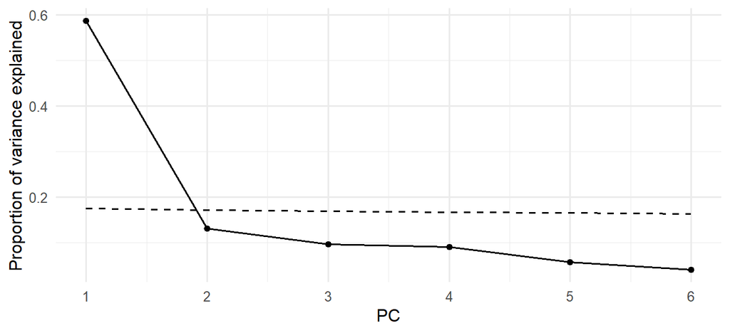

Scree plot: proportion of variance explained by each component of the six needs items (training days). The dashed line is the parallel-analysis cutoff on the same scale.

```r
ggplot(n_comp_rules, aes(PC, pve)) +
  geom_point() + geom_line() +
  geom_line(aes(y = random_95 / length(needs)), linetype = "dashed") +
  scale_x_continuous(breaks = seq_along(eig)) +
  labs(y = "Proportion of variance explained")
```

**Choosing the number.** The rules disagree, which the lecture notes is normal:

| Rule | Components kept |
| --- | --- |
| Scree plot | 1: the curve drops steeply from component 1 to 2 (58.6% to 13.1%) and flattens after that |
| Eigenvalue of 1 or more (lecture) | 1 |
| Eigenvalue of 0.75 or more (walkthrough) | 2 (the second eigenvalue is 0.78) |
| 80% of the variance | 3 (two components explain 71.7%, three 81.3%) |
| Parallel analysis | 1 (the second eigenvalue, 0.78, is below the random cutoff of 1.03) |
| Theory (self-determination theory) | 2: need satisfaction and need frustration |

Parallel analysis and the eigenvalue rule at 1 agree here, and with this much data they are close to the same test, so they count as one piece of evidence rather than two. Parallel analysis replaces the fixed cutoff of 1 with the eigenvalues of random data, which stray from 1 only by chance. With 8677 days and 6 items they barely stray (the cutoff for the second component is 1.03). The two rules part ways only when the sample is small or the items are many.

- **The case for one.** The first component alone explains 59% of the variance. It is a general “good day for my needs” dimension, with every satisfaction item positive and every frustration item negative.
- **We keep two**, as theory and the walkthrough’s cutoff say. Self-determination theory treats satisfaction and frustration as separate experiences, and the proposal predicted exactly these two dimensions. Two components also carry more of the frustration items, which the first component carries less well.
- **Section 8 checks** one and three components (the 80% rule’s choice) against two on the training folds.

```r
n_keep <- 2

loadings <- pca$rotation[, 1:n_keep] %*% diag(pca$sdev[1:n_keep])
colnames(loadings) <- paste0("PC", 1:n_keep)
round(loadings, 2)
```

```
##                                PC1   PC2
## needs_autonomy_satisfied      0.83 -0.34
## needs_autonomy_frustrated    -0.66 -0.53
## needs_competence_satisfied    0.83 -0.34
## needs_competence_frustrated  -0.78 -0.21
## needs_relatedness_satisfied   0.75 -0.29
## needs_relatedness_frustrated -0.73 -0.37
```

### Rotation and names

The unrotated pair is one general component plus a contrast, which is hard to name. A varimax rotation turns the two axes within the same plane. The variance they explain together does not change.

```r
rotation <- varimax(loadings)
rotated  <- unclass(rotation$loadings)
colnames(rotated) <- paste0("RC", 1:n_keep)

# flip each component so its strongest items load positively
flip <- sign(apply(rotated, 2, function(l) l[which.max(abs(l))]))
rotated <- sweep(rotated, 2, flip, "*")

# name each component by which kind of item it carries
sat_items  <- grepl("_satisfied$", rownames(rotated))
is_sat     <- colMeans(abs(rotated[sat_items, ])) > colMeans(abs(rotated[!sat_items, ]))
comp_names <- unname(ifelse(is_sat, "need_satisfaction", "need_frustration"))
stopifnot(!anyDuplicated(comp_names))
colnames(rotated) <- comp_names

round(rotated, 2)
```

```
##                              need_satisfaction need_frustration
## needs_autonomy_satisfied                  0.86            -0.28
## needs_autonomy_frustrated                -0.15             0.83
## needs_competence_satisfied                0.85            -0.28
## needs_competence_frustrated              -0.46             0.67
## needs_relatedness_satisfied               0.76            -0.27
## needs_relatedness_frustrated             -0.31             0.76
```

```r
# variance explained by the two rotated components together
round(sum(rotated^2) / length(needs), 3)
```

```
## [1] 0.717
```

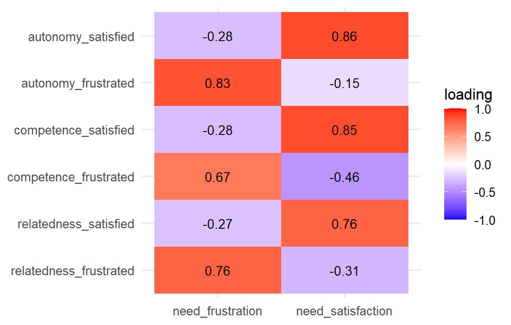

Rotated loadings of the six needs items on the two components.

```r
as.data.frame(rotated) %>%
  mutate(item = factor(sub("needs_", "", rownames(rotated)),
                       levels = rev(sub("needs_", "", rownames(rotated))))) %>%
  pivot_longer(-item, names_to = "component", values_to = "loading") %>%
  ggplot(aes(component, item, fill = loading)) +
  geom_tile() +
  geom_text(aes(label = sprintf("%.2f", loading)), size = 3.5) +
  scale_fill_gradient2(low = "blue", mid = "white", high = "red", limits = c(-1, 1)) +
  labs(x = NULL, y = NULL)
```

- **Need satisfaction.** The three satisfaction items (autonomy, competence, relatedness) load highly. A high score is a day the person did what they valued, did it well, and felt close to people.
- **Need frustration.** The three frustration items load highly (after the flip). A high score is a day the person felt forced, insecure, or excluded. Competence frustration loads on both components.

### Compared with the proposal

The proposal expected two components, one for general satisfaction and one for general frustration, rather than one for each need. It read that result as days differing “more in how fulfilling or frustrating they are overall rather than in which specific need is met.” Two numbers help check that reading: how strongly the satisfied and frustrated items go together, and what a third component would hold.

```r
needs_cor <- cor(train_needs)
sat <- grepl("_satisfied$", needs)

# correlations between each satisfied item and each frustrated item
round(range(needs_cor[sat, !sat]), 2)
```

```
## [1] -0.59 -0.36
```

```r
# three varimax-rotated components; the one that carries relatedness
# frustration most, flipped so that item loads positively (Section 8 tests
# whether a third component helps prediction)
L3 <- unclass(varimax(pca$rotation[, 1:3] %*% diag(pca$sdev[1:3]))$loadings)
rel_comp <- which.max(abs(L3["needs_relatedness_frustrated", ]))
third <- L3[, rel_comp] * sign(L3["needs_relatedness_frustrated", rel_comp])
round(third, 2)
```

```
##     needs_autonomy_satisfied    needs_autonomy_frustrated
##                        -0.18                         0.16
##   needs_competence_satisfied  needs_competence_frustrated
##                        -0.16                         0.37
##  needs_relatedness_satisfied needs_relatedness_frustrated
##                        -0.61                         0.85
```

- **What matches.** The two rotated components are need satisfaction and need frustration, as predicted. Each item loads mainly on its own side, and neither component belongs to a single need.
- **Satisfaction and frustration go together.** The first unrotated component alone explains 59% of the variance, and every satisfied item correlates between -0.59 and -0.36 with every frustrated item. A day that meets a person’s needs is usually also a day low in frustration. The two rotated scores are uncorrelated only because varimax keeps the axes at right angles. That is a property of the method, not a finding.
- **One need partly stands apart: relatedness.** A third component, the one the 80% rule would keep, is mostly relatedness: relatedness frustration loads 0.85 and relatedness satisfaction -0.61. It is small (eigenvalue 0.58, 9.6% of the variance), and Section 8 shows it adds nothing to predicting life satisfaction. Autonomy and competence cannot be told apart: their satisfaction items correlate 0.75.
- **Days and people.** The components are fit on days pooled across people, so they mix differences between people with differences between one person’s days. A high need-satisfaction score marks a good day partly because it marks a person whose days usually go well.

The proposal’s reading holds, with one qualification: the days differ mostly in how fulfilling they are overall, but relatedness carries a little variance of its own. These components are **dimensions** of a day. The **types** of days come from the clustering in Section 6a.

### Scores for every day

Test scores use the training weights, the training SDs, and the same rotation and flip.

```r
component_scores <- function(block) {
  raw <- predict(pca, newdata = block)[, 1:n_keep, drop = FALSE]
  standardized <- sweep(raw, 2, pca$sdev[1:n_keep], "/")
  out <- sweep(standardized %*% rotation$rotmat, 2, flip, "*")
  colnames(out) <- comp_names
  out
}

train <- bind_cols(train, as.data.frame(component_scores(train_needs)))
test  <- bind_cols(test,  as.data.frame(component_scores(test_needs)))

round(rbind(train_mean = colMeans(train[comp_names]),
            train_sd   = sapply(train[comp_names], sd),
            test_mean  = colMeans(test[comp_names])), 2)
```

```
##            need_satisfaction need_frustration
## train_mean              0.00             0.00
## train_sd                1.00             1.00
## test_mean               0.04            -0.05
```

```r
# days with no needs answers were filled with the training medians, so they
# all get the same two scores
unique(round(as.data.frame(train)[rowSums(is.na(train[needs])) > 0, comp_names], 2))
```

|  | need_satisfaction | need_frustration |
| --- | --- | --- |
| 3464 | 0.01 | -0.27 |

### Components, clusters, and the target (training days)

```r
train %>%
  group_by(play_day_type) %>%
  summarise(days = n(), across(all_of(comp_names), ~ round(mean(.x), 2))) %>%
  as.data.frame()
```

| play_day_type | days | need_satisfaction | need_frustration |
| --- | --- | --- | --- |
| Smooth solo play day | 2037 | -0.13 | -0.21 |
| Connected play day | 3986 | 0.28 | -0.23 |
| Frustrating play day | 2654 | -0.32 | 0.50 |

```r
round(cor(train[c(comp_names, "life_satisfaction")]), 2)
```

```
##                   need_satisfaction need_frustration life_satisfaction
## need_satisfaction              1.00              0.0              0.66
## need_frustration               0.00              1.0             -0.40
## life_satisfaction              0.66             -0.4              1.00
```

Need satisfaction is strongly related to life satisfaction on the same day. That is expected, and Section 7 discusses what it means for the model. Need frustration is related more weakly, and in the opposite direction. The play-day types line up with the components: frustrating play days are lower on need satisfaction and higher on need frustration. The two blocks describe overlapping but different parts of the day.

# 7. Feature Sets and Leakage

## Feature sets A and B

Both sets share every predictor that is not in the needs block, including the six BANGS items:

- **Set A** adds the six needs items.
- **Set B** replaces the six needs items with their two component scores and adds the play-day type (the cluster) as a factor, as the handout defines set B.

The clustering block is a chosen set of predictors (the BANGS items), not the PCA block, as the handout allows. So the BANGS items stay in both sets, and the A versus B comparison asks two things. Do two scores carry what the six needs items carry? Does the play-day type add anything to the items it was built from?

```r
shared <- c(bangs, day_preds, person_preds)
set_A  <- c(shared, needs)
set_B  <- c(shared, comp_names, "play_day_type")

c(A = length(set_A), B = length(set_B))
```

```
##  A  B
## 32 29
```

```r
setdiff(set_A, set_B)
```

```
## [1] "needs_autonomy_satisfied"     "needs_autonomy_frustrated"
## [3] "needs_competence_satisfied"   "needs_competence_frustrated"
## [5] "needs_relatedness_satisfied"  "needs_relatedness_frustrated"
```

```r
setdiff(set_B, set_A)
```

```
## [1] "need_satisfaction" "need_frustration"  "play_day_type"
```

```r
train_A <- train[c("life_satisfaction", set_A)]
train_B <- train[c("life_satisfaction", set_B)]
test_A  <- test[c("life_satisfaction", set_A)]
test_B  <- test[c("life_satisfaction", set_B)]
```

## Data leakage we considered

- **The target in another form.** Affective valence (r = 0.87 with life satisfaction) was removed.
  - The needs items are kept, as the proposal planned. They ask about the day’s experiences (doing what one values, feeling close to people), not about satisfaction with life. But they are answered in the same sitting, and need satisfaction correlates 0.66 with the target. Much of the model’s accuracy will come from them, and that accuracy describes what goes together on a day. It does not show that needs cause life satisfaction.
  - No block contains the target, so no cluster or component is built from it.
- **Lags.** Every daily predictor is from the same day, so there is no lag that could reach forward into the next day.
- **Repeated measures.** The split and the folds hold out whole people (Section 5).
- **Preprocessing.** Imputation, dummy coding, and scaling are in recipes, re-learned inside each fold. The recoding in Section 3 learns nothing from the data.
- **Unsupervised structure.** The clusters and components were fit on the training days only, and the test days were scored from that fit.
  - One smaller issue remains inside cross-validation. The cluster centroids, the component weights, and the medians that fill the blocks were learned from all training days, so in each fold the held-out days helped shape them.
  - The structure never uses the target, and six items fit on about 8,700 days barely move when a tenth of them are held out. So the effect on the cross-validated comparison should be negligible.
  - The test set is untouched by this.
- **Information from the future.** The intake survey must come before the diary days it describes:

```r
intake_time <- as.POSIXct(train$intake_date, format = "%Y-%m-%dT%H:%M:%SZ", tz = "UTC")
gap_days    <- as.numeric(difftime(train$date, intake_time, units = "days"))
summary(gap_days)
```

```
##    Min. 1st Qu.  Median    Mean 3rd Qu.    Max.     NAs
##   4.926  32.802  42.195  50.852  55.104 192.105     114
```

```r
c(diary_days_before_intake = sum(gap_days < 0, na.rm = TRUE))
```

```
## diary_days_before_intake
##                        0
```

# 8. Supervised Models

## Recipes

```r
# regularized regression: dummy columns and standardized predictors
recipe_linear <- function(dat) {
  recipe(life_satisfaction ~ ., data = dat) %>%
    step_impute_median(age, education) %>%
    step_impute_knn(all_predictors(), neighbors = 5) %>%
    step_dummy(all_nominal_predictors()) %>%
    step_zv(all_predictors()) %>%
    step_normalize(all_numeric_predictors())
}

# trees: the same imputation, factors kept whole, no scaling
recipe_tree <- function(dat) {
  recipe(life_satisfaction ~ ., data = dat) %>%
    step_impute_median(age, education) %>%
    step_impute_knn(all_predictors(), neighbors = 5) %>%
    step_zv(all_predictors())
}

rec <- list(linear_A = recipe_linear(train_A), linear_B = recipe_linear(train_B),
            tree_A   = recipe_tree(train_A),   tree_B   = recipe_tree(train_B))

# prep once to check the recipes and count the columns each model sees
baked <- lapply(rec, function(r) bake(prep(r), new_data = NULL))
sapply(baked, function(b) c(columns = ncol(b) - 1, missing_left = sum(is.na(b))))
```

```
##              linear_A linear_B tree_A tree_B
## columns            54       52     32     29
## missing_left        0        0      0      0
```

- **Imputation.** Age and education get the training median, because they are constant within a person. Everything else is imputed with five nearest neighbors, never using the target.
- **The ordered stressor factor** becomes polynomial contrasts for the elastic net. The trees split it only between neighboring levels.
- **The trees** do not need dummy columns or scaling.

## Models and tuning grids

The handout requires a null model, a regularized regression with `glmnet`, and a tree ensemble. As in the course walkthrough, we fit the null model, the elastic net, and the random forest, on both feature sets, with the same 10 grouped folds and the same seeds. The folds are fit in parallel, so the random parts of each fit are fixed by the seeds list in `trainControl()` (Section 5), which is drawn from `set.seed(559)`.

**Reproducibility.** We checked this by refitting. The null model, both elastic nets, both random forests, and every check in this section reproduce exactly.

[output not shown]

A helper reports whether each best tuning value is inside its grid or at an edge. A best value at an edge would mean the grid should be widened.

```r
edge_check <- function(fit) {
  sapply(names(fit$bestTune), function(v) {
    vals <- sort(unique(fit$results[[v]]))
    b    <- fit$bestTune[[v]]
    if (length(vals) == 1) "fixed"
    else if (b == min(vals)) "lowest value tried"
    else if (b == max(vals)) "highest value tried"
    else "interior"
  })
}

# fit a model, or read the saved fit. set.seed(559) stays right before each
# train() call, as in the walkthrough; the seeds in `ctrl` are what fix the
# parallel fits
fit_dir <- out_path("model_fits")
dir.create(fit_dir, showWarnings = FALSE)

# The recipe's column selectors keep a link to the R session they were made
# in, so a saved fit can carry a copy of every object in the session (over
# 100 MB a file). Pointing them at the global environment before saving keeps
# each file small. Nothing after the fit uses that link: the cross-validated
# results and the predictions are unchanged.
drop_session <- function(x) {
  if (rlang::is_quosure(x)) return(rlang::quo_set_env(x, globalenv()))
  if (is.list(x) && !is.data.frame(x)) {
    a <- attributes(x)
    x <- lapply(x, drop_session)
    attributes(x) <- a
  }
  x
}

fit_or_load <- function(name, expr) {
  file <- file.path(fit_dir, paste0(name, ".rds"))
  if (!refit_models && file.exists(file)) return(readRDS(file))
  fit <- expr                       # evaluated here, so the fit runs only when needed
  fit$recipe$steps <- lapply(fit$recipe$steps, drop_session)
  saveRDS(fit, file)
  fit
}

# fit the folds in parallel: caret sends each fold to its own R worker. The
# seeds in `ctrl` (drawn from set.seed(559)) fix the random parts of each
# fit whatever the number of cores. Two cores
# are left free for the rest of the computer.
n_workers <- max(1, min(n_folds, parallel::detectCores() - 2))
cl <- makePSOCKcluster(n_workers)
registerDoParallel(cl)
```

## Null model

```r
fit_null <- fit_or_load("null", {
  set.seed(559)
  train(rec$linear_A, data = train_A, method = "null", trControl = ctrl)
})
getTrainPerf(fit_null)
```

| TrainRMSE | TrainRsquared | TrainMAE | method |
| --- | --- | --- | --- |
| 24.09772 | NaN | 19.2927 | null |

## Elastic net

```r
lambda_grid <- function(b) {
  x <- as.matrix(b[names(b) != "life_satisfaction"])
  lambda_max <- max(glmnet(x, b$life_satisfaction, alpha = 1)$lambda)
  10^seq(log10(lambda_max) - 4, log10(lambda_max) + 1, length.out = 60)
}

fit_glmnet_A <- fit_or_load("glmnet_A", {
  set.seed(559)
  train(rec$linear_A, data = train_A, method = "glmnet", trControl = ctrl,
        tuneGrid = expand.grid(alpha = seq(0, 1, 0.25),
                               lambda = lambda_grid(baked$linear_A)))
})
fit_glmnet_B <- fit_or_load("glmnet_B", {
  set.seed(559)
  train(rec$linear_B, data = train_B, method = "glmnet", trControl = ctrl,
        tuneGrid = expand.grid(alpha = seq(0, 1, 0.25),
                               lambda = lambda_grid(baked$linear_B)))
})

rbind(A = cbind(fit_glmnet_A$bestTune, t(edge_check(fit_glmnet_A))),
      B = cbind(fit_glmnet_B$bestTune, t(edge_check(fit_glmnet_B))))
```

|  | alpha | lambda | alpha | lambda |
| --- | --- | --- | --- | --- |
| A | 0.25 | 0.8518604 | interior | interior |
| B | 0.75 | 0.3087450 | interior | interior |

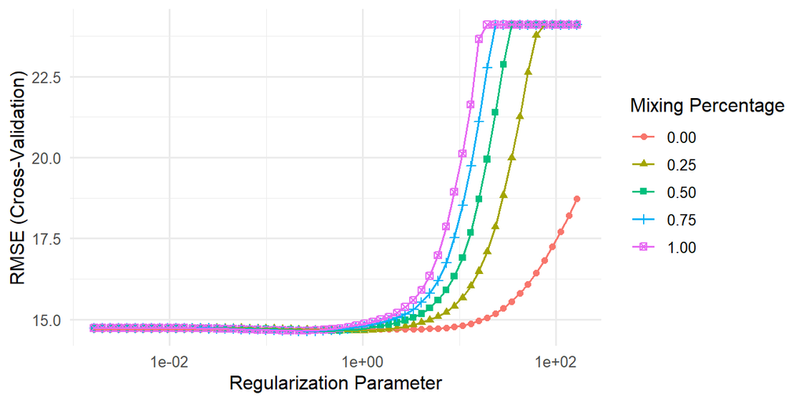

Elastic net: cross-validated RMSE across lambda, one line per alpha (feature set A).

```r
ggplot(fit_glmnet_A) + scale_x_log10()
```

## Random forest

```r
# widened after the first run (see the table above): p added to mtry, and
# 100 and 200 added to min.node.size
rf_grid <- function(p) {
  expand.grid(mtry = sort(unique(pmax(2, round(c(2, sqrt(p), p / 3, p / 2, p))))),
              splitrule = "variance",
              min.node.size = c(5, 20, 50, 100, 200))
}
p_A <- ncol(baked$tree_A) - 1
p_B <- ncol(baked$tree_B) - 1

fit_rf_A <- fit_or_load("rf_A", {
  set.seed(559)
  train(rec$tree_A, data = train_A, method = "ranger", trControl = ctrl,
        tuneGrid = rf_grid(p_A), num.trees = 500, importance = "impurity",
        respect.unordered.factors = "order",
        num.threads = 1)   # one thread per fold; the folds already run in parallel
})
fit_rf_B <- fit_or_load("rf_B", {
  set.seed(559)
  train(rec$tree_B, data = train_B, method = "ranger", trControl = ctrl,
        tuneGrid = rf_grid(p_B), num.trees = 500, importance = "impurity",
        respect.unordered.factors = "order",
        num.threads = 1)
})

rbind(A = cbind(fit_rf_A$bestTune, t(edge_check(fit_rf_A))),
      B = cbind(fit_rf_B$bestTune, t(edge_check(fit_rf_B))))
```

|  | mtry | splitrule | min.node.size | mtry | splitrule | min.node.size |
| --- | --- | --- | --- | --- | --- | --- |
| A | 6 | variance | 5 | interior | fixed | lowest value tried |
| B | 14 | variance | 50 | interior | fixed | interior |

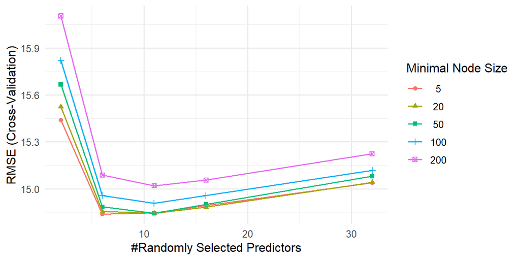

Random forest: cross-validated RMSE across mtry and minimum node size (feature set A).

```r
ggplot(fit_rf_A)
```

**Edges.** The edge labels in the tables above show whether each best tuning value was inside its grid. Both elastic nets’ best `alpha` and `lambda` are inside the grid.

```r
# set A's forest at its best mtry, across node sizes (used below)
rf_A_nodes <- filter(fit_rf_A$results, mtry == fit_rf_A$bestTune$mtry)
```

**The random forest.** Its grid was widened after the first run’s best values landed on the top edge (see the grid table).

## The cross-validated comparison

Every model used the same folds, so `resamples()` lines them up fold by fold.

```r
fits <- list(null = fit_null,
             glmnet_A = fit_glmnet_A, glmnet_B = fit_glmnet_B,
             rf_A = fit_rf_A, rf_B = fit_rf_B)

model_label <- c(null = "Null", glmnet = "Elastic net", rf = "Random forest")

results_cv <- resamples(fits)
summary(results_cv)$statistics$RMSE |> round(3)
```

```
##            Min. 1st Qu. Median   Mean 3rd Qu.   Max. NA's
## null     21.780  22.509 23.482 24.098  25.537 27.615    0
## glmnet_A 12.704  14.112 14.710 14.649  14.943 16.654    0
## glmnet_B 12.811  14.078 14.691 14.629  14.829 16.566    0
## rf_A     13.503  14.252 14.613 14.839  15.368 17.156    0
## rf_B     13.648  14.508 14.970 14.991  15.146 16.974    0
```

The table the report needs: one row per model and feature set, with the mean over the folds and the fold-to-fold spread (SD) of each metric.

```r
# per-fold values of one metric, one column per model
fold_values <- function(metric) {
  v <- results_cv$values[, grep(paste0("~", metric, "$"), names(results_cv$values))]
  names(v) <- sub(paste0("~", metric), "", names(v))
  v
}

rmse_folds <- fold_values("RMSE")
r2_folds   <- fold_values("Rsquared")
mae_folds  <- fold_values("MAE")

cv_table <- data.frame(
  model       = unname(model_label[sub("_.*", "", names(rmse_folds))]),
  feature_set = ifelse(names(rmse_folds) == "null", "none", sub(".*_", "", names(rmse_folds))),
  RMSE        = colMeans(rmse_folds),
  RMSE_SD     = apply(rmse_folds, 2, sd),
  Rsquared    = colMeans(r2_folds),      # NA for the null model: its predictions do not vary
  Rsquared_SD = apply(r2_folds, 2, sd),
  MAE         = colMeans(mae_folds),
  MAE_SD      = apply(mae_folds, 2, sd),
  row.names   = NULL) %>%
  arrange(RMSE)

cv_table %>% mutate(across(where(is.numeric), ~ round(.x, 3)))
```

| model | feature_set | RMSE | RMSE_SD | Rsquared | Rsquared_SD | MAE | MAE_SD |
| --- | --- | --- | --- | --- | --- | --- | --- |
| Elastic net | B | 14.629 | 1.046 | 0.623 | 0.070 | 11.117 | 0.727 |
| Elastic net | A | 14.649 | 1.094 | 0.622 | 0.070 | 11.129 | 0.757 |
| Random forest | A | 14.839 | 1.121 | 0.621 | 0.068 | 11.394 | 0.700 |
| Random forest | B | 14.991 | 0.975 | 0.607 | 0.069 | 11.457 | 0.580 |
| Null | none | 24.098 | 1.995 | NA | NA | 19.293 | 1.332 |

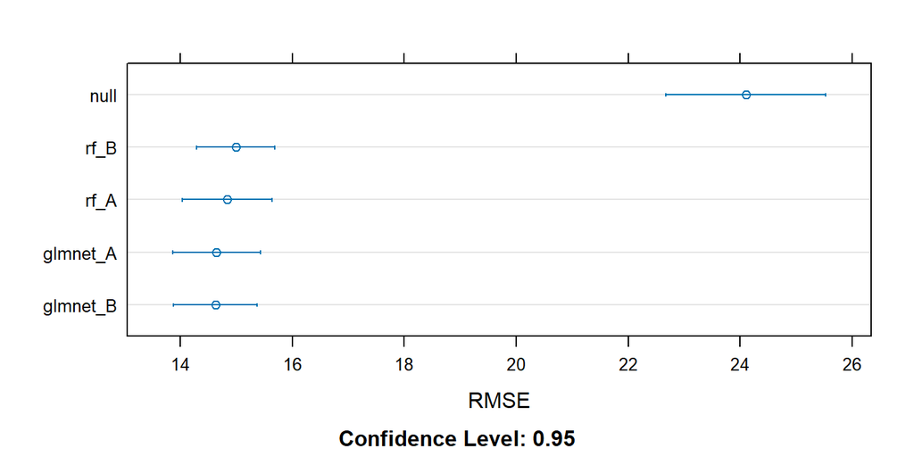

Cross-validated RMSE by model, with 95% confidence intervals across folds.

```r
dotplot(results_cv, metric = "RMSE")
```

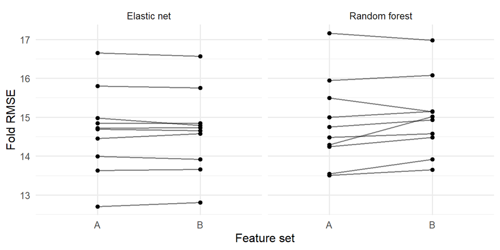

Cross-validated RMSE per fold, by model and feature set. Each line is one fold.

```r
# one row per fold and model, for the plot and the saved results
cv_long <- data.frame(fold = results_cv$values$Resample, rmse_folds, check.names = FALSE) %>%
  pivot_longer(-fold, names_to = "key", values_to = "RMSE") %>%
  mutate(model       = unname(model_label[sub("_.*", "", key)]),
         feature_set = ifelse(key == "null", "none", sub(".*_", "", key)))

cv_long %>%
  filter(key != "null") %>%
  ggplot(aes(feature_set, RMSE, group = fold)) +
  geom_line(alpha = 0.5) + geom_point() +
  facet_wrap(~ model) +
  labs(x = "Feature set", y = "Fold RMSE")
```

### Did the unsupervised features help? Set A versus set B, fold by fold

The same folds scored both feature sets, so the fair comparison is within each fold. For each model, the difference is set A’s fold RMSE minus set B’s on the same fold, as in the course walkthrough:

```r
# each fit's fold RMSEs, in fold order
fold_rmse <- function(fit) fit$resample[order(fit$resample$Resample), "RMSE"]

# A minus B on each fold
ab <- data.frame(
  fold   = sort(fit_glmnet_A$resample$Resample),
  glmnet = fold_rmse(fit_glmnet_A) - fold_rmse(fit_glmnet_B),
  rf     = fold_rmse(fit_rf_A)     - fold_rmse(fit_rf_B))

ab %>% mutate(across(where(is.numeric), ~ round(.x, 3)))
```

| fold | glmnet | rf |
| --- | --- | --- |
| Fold01 | -0.027 | -0.376 |
| Fold02 | -0.003 | -0.151 |
| Fold03 | 0.194 | 0.352 |
| Fold04 | -0.117 | -0.182 |
| Fold05 | 0.088 | 0.182 |
| Fold06 | 0.046 | -0.134 |
| Fold07 | -0.107 | -0.145 |
| Fold08 | 0.084 | -0.722 |
| Fold09 | 0.045 | -0.092 |
| Fold10 | -0.006 | -0.247 |

```r
# mean difference (A minus B), its spread across folds, and the 2 SE rule
diffs  <- ab[-1]
a_vs_b <- data.frame(
  model          = unname(model_label[names(diffs)]),
  RMSE_A         = sapply(names(diffs), function(m) mean(fold_rmse(fits[[paste0(m, "_A")]]))),
  RMSE_B         = sapply(names(diffs), function(m) mean(fold_rmse(fits[[paste0(m, "_B")]]))),
  A_minus_B      = colMeans(diffs),
  sd_diff        = apply(diffs, 2, sd),
  two_SE         = 2 * apply(diffs, 2, sd) / sqrt(nrow(diffs)),
  folds_B_better = colSums(diffs > 0),
  row.names      = NULL)
a_vs_b$beyond_noise <- abs(a_vs_b$A_minus_B) > a_vs_b$two_SE

a_vs_b %>% mutate(across(where(is.numeric), ~ round(.x, 3)))
```

| model | RMSE_A | RMSE_B | A_minus_B | sd_diff | two_SE | folds_B_better | beyond_noise |
| --- | --- | --- | --- | --- | --- | --- | --- |
| Elastic net | 14.649 | 14.629 | 0.020 | 0.093 | 0.059 | 5 | FALSE |
| Random forest | 14.839 | 14.991 | -0.152 | 0.290 | 0.183 | 2 | FALSE |

### Checking the cluster and component choices

The number of clusters and the number of components were chosen in Section 6 from the elbow, the silhouette, and the eigenvalue rules. This section checks those choices against the alternatives: K = 2 and K = 4 clusters, and one or three components. Everything here uses the training days and the same 10 folds. The test set is not touched.

Each check refits the final model type, the elastic net on set B, with one piece of set B swapped and everything else held fixed.

```r
# set B with one piece swapped; NULL leaves that piece out
set_B_variant <- function(types = train$play_day_type,
                          needs_block = train[comp_names]) {
  d <- train[c("life_satisfaction", shared)]
  if (!is.null(needs_block)) d <- bind_cols(d, needs_block)
  if (!is.null(types)) d$play_day_type <- types
  d
}

# the same recipe, grid, folds, and seed as fit_glmnet_B
fit_glmnet_check <- function(name, d) {
  fit_or_load(name, {
    r <- recipe_linear(d)
    b <- bake(prep(r), new_data = NULL)
    set.seed(559)
    train(r, data = d, method = "glmnet", trControl = ctrl,
          tuneGrid = expand.grid(alpha = seq(0, 1, 0.25),
                                 lambda = lambda_grid(b)))
  })
}

# fold-by-fold comparison with the chosen version, read like A minus B:
# chosen minus variant on each fold, so positive = the variant did better
check_table <- function(fit_list, chosen) {
  ref <- fold_rmse(fit_list[[chosen]])
  do.call(rbind, lapply(names(fit_list), function(n) {
    r <- fold_rmse(fit_list[[n]])
    d <- ref - r
    data.frame(variant = n, RMSE = mean(r),
               Rsquared = mean(fit_list[[n]]$resample$Rsquared),
               chosen_minus_variant = mean(d),
               two_SE = 2 * sd(d) / sqrt(length(d)),
               folds_variant_better = sum(d > 0))
  })) %>%
    mutate(across(where(is.numeric), ~ round(.x, 3)))
}
```

#### Clusters: K = 2, 3, and 4

The K = 2 and K = 4 types are named by rules, like the K = 3 types:

- **K = 2.** The cluster with higher autonomy is the **good play day**, and the other is the **bad play day**.
- **K = 4.**
  - The highest relationships mean is the **connected play day**.
  - Of the rest, the lowest autonomy is the **stalled play day**.
  - Of the remaining two, the higher toxicity is the **toxic social play day**.
  - The last is the **smooth solo play day**.

```r
name_k2 <- function(prof) {
  ifelse(prof$gaming_autonomy == max(prof$gaming_autonomy),
         "Good play day", "Bad play day")
}
name_k4 <- function(prof) {
  connected <- which.max(prof$gaming_relationships)
  rest      <- setdiff(seq_len(nrow(prof)), connected)
  stalled   <- rest[which.min(prof$gaming_autonomy[rest])]
  rest      <- setdiff(rest, stalled)
  toxic     <- rest[which.max(prof$gaming_toxic[rest])]
  nm <- character(nrow(prof))
  nm[c(connected, stalled, toxic, setdiff(rest, toxic))] <-
    c("Connected play day", "Stalled play day", "Toxic social play day",
      "Smooth solo play day")
  nm
}

k_labels <- list(`2` = name_k2(cluster_profile(km_fits[[2]]$cluster)),
                 `3` = cluster_names,
                 `4` = name_k4(cluster_profile(km_fits[[4]]$cluster)))
k_type <- function(k) k_labels[[as.character(k)]][km_fits[[k]]$cluster]

k_profiles <- bind_rows(lapply(2:4, function(k) {
  cl <- km_fits[[k]]$cluster
  cluster_profile(cl) %>%
    mutate(K = k, type = k_labels[[as.character(k)]][cluster],
           pct_days = round(100 * days / sum(days)),
           mean_life_sat = round(as.numeric(tapply(train$life_satisfaction, cl, mean)), 1)) %>%
    select(K, type, days, pct_days, mean_life_sat, all_of(bangs))
}))
k_profiles
```

| K | type | days | pct_days | mean_life_sat | gaming_autonomy | gaming_wish_else | gaming_progress | gaming_disappointed | gaming_relationships | gaming_toxic |
| --- | --- | --- | --- | --- | --- | --- | --- | --- | --- | --- |
| 2 | Good play day | 5600 | 65 | 71.1 | 6.2 | 1.7 | 6.0 | 1.6 | 4.0 | 1.5 |
| 2 | Bad play day | 3077 | 35 | 55.9 | 4.6 | 3.6 | 4.3 | 3.5 | 3.3 | 3.0 |
| 3 | Connected play day | 3986 | 46 | 72.7 | 6.2 | 1.7 | 6.0 | 1.7 | 5.1 | 1.7 |
| 3 | Frustrating play day | 2654 | 31 | 55.5 | 4.6 | 3.7 | 4.3 | 3.7 | 3.4 | 3.2 |
| 3 | Smooth solo play day | 2037 | 23 | 65.3 | 6.0 | 1.9 | 5.6 | 1.7 | 1.5 | 1.3 |
| 4 | Stalled play day | 1357 | 16 | 49.9 | 3.8 | 4.0 | 3.6 | 4.1 | 2.8 | 2.9 |
| 4 | Smooth solo play day | 1998 | 23 | 65.3 | 6.0 | 1.9 | 5.6 | 1.7 | 1.5 | 1.2 |
| 4 | Connected play day | 3254 | 38 | 73.6 | 6.3 | 1.6 | 6.2 | 1.5 | 5.2 | 1.4 |
| 4 | Toxic social play day | 2068 | 24 | 64.0 | 5.5 | 3.0 | 5.2 | 2.9 | 4.3 | 3.4 |

```r
# how each solution splits the one before it (training days)
table(K2 = k_type(2), K3 = k_type(3))
```

```
##                K3
## K2              Connected play day Frustrating play day Smooth solo play day
##   Bad play day                 105                 2654                  318
##   Good play day               3881                    0                 1719
```

```r
table(K3 = k_type(3), K4 = k_type(4))
```

```
##                       K4
## K3                     Connected play day Smooth solo play day Stalled play day
##   Connected play day                 3251                   29                0
##   Frustrating play day                  0                   18             1343
##   Smooth solo play day                  3                 1951               14
##                       K4
## K3                     Toxic social play day
##   Connected play day                     706
##   Frustrating play day                  1293
##   Smooth solo play day                    69
```

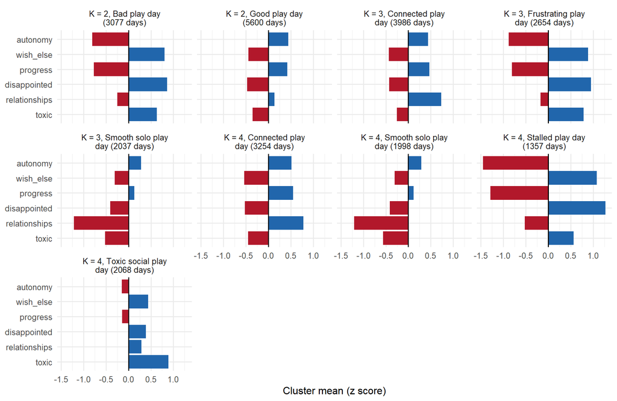

Cluster centroids on the six BANGS items for K = 2, 3, and 4 (z scores, training days).

```r
bind_rows(lapply(2:4, function(k) {
  as.data.frame(km_fits[[k]]$centers) %>%
    mutate(K = paste("K =", k),
           type = paste0(k_labels[[as.character(k)]], "\n(", km_fits[[k]]$size, " days)"))
})) %>%
  pivot_longer(all_of(bangs), names_to = "item", values_to = "z") %>%
  mutate(item = factor(sub("gaming_", "", item),
                       levels = rev(sub("gaming_", "", bangs)))) %>%
  ggplot(aes(z, item, fill = z > 0)) +
  geom_col() + geom_vline(xintercept = 0) +
  facet_wrap(~ K + type, ncol = 4, labeller = label_wrap_gen(multi_line = FALSE)) +
  scale_fill_manual(values = c("#b2182b", "#2166ac"), guide = "none") +
  labs(x = "Cluster mean (z score)", y = NULL)
```

**Stability.** A real type should come back when the data change a little. K-means is refit on 20 random samples of 80% of the training people. All training days are then assigned to the nearest centroid of that fit and compared with the full solution by the adjusted Rand index (1 = the same partition, 0 = chance agreement).

```r
adjusted_rand <- function(a, b) {
  tab <- table(a, b)
  n   <- sum(tab)
  s   <- sum(choose(tab, 2))
  sa  <- sum(choose(rowSums(tab), 2))
  sb  <- sum(choose(colSums(tab), 2))
  expected <- sa * sb / choose(n, 2)
  (s - expected) / ((sa + sb) / 2 - expected)
}

train_people <- unique(train$id)
set.seed(559)
k_stability <- sapply(2:4, function(k) {
  replicate(20, {
    keep <- train$id %in% sample(train_people, round(0.8 * length(train_people)))
    sub_fit <- kmeans(train_bangs[keep, ], centers = k, nstart = 25, iter.max = 50)
    adjusted_rand(nearest_centroid(train_bangs, sub_fit$centers), km_fits[[k]]$cluster)
  })
})
colnames(k_stability) <- paste0("K", 2:4)

k_stability_table <- data.frame(
  K = 2:4,
  silhouette = round(k_choice$silhouette[2:4], 3),
  wss_share_of_k1 = round(k_choice$wss[2:4] / k_choice$wss[1], 3),
  stability_mean = round(colMeans(k_stability), 3),
  stability_min  = round(apply(k_stability, 2, min), 3),
  life_sat_r2 = round(sapply(2:4, function(k)
    summary(lm(train$life_satisfaction ~ factor(km_fits[[k]]$cluster)))$r.squared), 3))
k_stability_table
```

|  | K | silhouette | wss_share_of_k1 | stability_mean | stability_min | life_sat_r2 |
| --- | --- | --- | --- | --- | --- | --- |
| K2 | 2 | 0.292 | 0.716 | 0.970 | 0.925 | 0.090 |
| K3 | 3 | 0.218 | 0.620 | 0.972 | 0.928 | 0.093 |
| K4 | 4 | 0.211 | 0.559 | 0.911 | 0.789 | 0.108 |

**Prediction.** The elastic net on set B with the play-day type from each K, and without it:

```r
check_k_fits <- list(
  no_play_day_type = fit_glmnet_check("check_no_type", set_B_variant(types = NULL)),
  K2              = fit_glmnet_check("check_K2", set_B_variant(types = factor(k_type(2)))),
  K3_chosen       = fit_glmnet_B,
  K4              = fit_glmnet_check("check_K4", set_B_variant(types = factor(k_type(4)))))

check_k_table <- check_table(check_k_fits, "K3_chosen")
check_k_table
```

| variant | RMSE | Rsquared | chosen_minus_variant | two_SE | folds_variant_better |
| --- | --- | --- | --- | --- | --- |
| no_play_day_type | 14.627 | 0.623 | 0.002 | 0.021 | 5 |
| K2 | 14.632 | 0.623 | -0.003 | 0.011 | 4 |
| K3_chosen | 14.629 | 0.623 | 0.000 | 0.000 | 0 |
| K4 | 14.633 | 0.623 | -0.004 | 0.016 | 3 |

```r
# the play-day-type coefficients the elastic net kept (standardized dummies)
type_coefs <- lapply(check_k_fits[-1], function(f) {
  cf <- as.matrix(coef(f$finalModel, f$bestTune$lambda))
  round(cf[grep("^play_day_type", rownames(cf)), 1], 2)
})
type_coefs
```

```
## $K2
## [1] 0
##
## $K3_chosen
##   play_day_type_Connected.play.day play_day_type_Frustrating.play.day
##                                  0                                  0
##
## $K4
##  play_day_type_Smooth.solo.play.day      play_day_type_Stalled.play.day
##                                0.00                               -0.22
## play_day_type_Toxic.social.play.day
##                                0.05
```

**What the check shows.**

- **K = 2** separates good play days from bad ones. It has the highest silhouette (0.292), but it hides the difference between connected and solo play. K = 3 recovers that difference, and the two good types differ in life satisfaction.
- **K = 4** is a finer cut. It splits the frustrating play days into a **toxic social** type and a **stalled** type. These are the days with the “toxic competitive” and “low improvement” sessions the proposal expected. It also moves some connected play days into the toxic social type. The criteria do not support the extra split:
  - the silhouette is no better (0.211 against 0.218 at K = 3);
  - the solution is less stable (mean adjusted Rand 0.911 against 0.972);
  - it explains little more of life satisfaction (R² = 0.108 against 0.093).
- **K = 3 is kept.** It is as stable as K = 2 (mean adjusted Rand 0.972 against 0.970), it sits at the elbow, and its types are distinct enough to name.
- **The number of clusters does not change prediction.** Every version is within 0.004 RMSE of the chosen one, and the largest two-SE band is 0.021. Dropping the play-day type entirely changes nothing either. The clusters are built from the six BANGS items, and set B already contains those items. So the play-day type describes the days but gives the model nothing new.

#### Components: one, two, or three

```r
# scores for m components, built the same way as the chosen two:
# standardized, varimax-rotated when m > 1, and flipped so the strongest
# loading is positive
pca_alternative <- function(m) {
  L <- pca$rotation[, 1:m, drop = FALSE] %*% diag(pca$sdev[1:m], m)
  rotmat <- diag(m)
  if (m > 1) {
    v <- varimax(L)
    L <- unclass(v$loadings)
    rotmat <- v$rotmat
  }
  fl <- sign(apply(L, 2, function(l) l[which.max(abs(l))]))
  L  <- sweep(L, 2, fl, "*")
  colnames(L) <- paste0("C", 1:m)
  sc <- sweep(predict(pca, newdata = train_needs)[, 1:m, drop = FALSE],
              2, pca$sdev[1:m], "/")
  sc <- sweep(sc %*% rotmat, 2, fl, "*")
  colnames(sc) <- colnames(L)
  list(loadings = L, scores = as.data.frame(sc), communality = rowSums(L^2))
}

pc_alt <- lapply(1:3, pca_alternative)

# loadings of the one- and three-component solutions
round(pc_alt[[1]]$loadings, 2)
```

```
##                                 C1
## needs_autonomy_satisfied      0.83
## needs_autonomy_frustrated    -0.66
## needs_competence_satisfied    0.83
## needs_competence_frustrated  -0.78
## needs_relatedness_satisfied   0.75
## needs_relatedness_frustrated -0.73
```

```r
round(pc_alt[[3]]$loadings, 2)
```

```
##                                 C1    C2    C3
## needs_autonomy_satisfied      0.86 -0.27 -0.18
## needs_autonomy_frustrated    -0.19  0.88  0.16
## needs_competence_satisfied    0.86 -0.29 -0.16
## needs_competence_frustrated  -0.43  0.59  0.37
## needs_relatedness_satisfied   0.64  0.01 -0.61
## needs_relatedness_frustrated -0.15  0.39  0.85
```

```r
# share of each item's variance the retained components carry
pc_communality <- round(sapply(pc_alt, `[[`, "communality"), 2)
colnames(pc_communality) <- paste(1:3, "comp.")
pc_communality
```

```
##                              1 comp. 2 comp. 3 comp.
## needs_autonomy_satisfied        0.69    0.81    0.84
## needs_autonomy_frustrated       0.43    0.71    0.84
## needs_competence_satisfied      0.69    0.80    0.85
## needs_competence_frustrated     0.61    0.66    0.66
## needs_relatedness_satisfied     0.56    0.65    0.79
## needs_relatedness_frustrated    0.53    0.67    0.90
```

```r
check_pc_fits <- list(
  one_component          = fit_glmnet_check("check_PC1", set_B_variant(needs_block = pc_alt[[1]]$scores)),
  two_components_chosen  = fit_glmnet_B,
  three_components       = fit_glmnet_check("check_PC3", set_B_variant(needs_block = pc_alt[[3]]$scores)),
  six_needs_items        = fit_glmnet_check("check_raw_needs", set_B_variant(needs_block = train[needs])),
  no_needs_items         = fit_glmnet_check("check_no_needs", set_B_variant(needs_block = NULL)))

check_pc_table <- check_table(check_pc_fits, "two_components_chosen")
check_pc_table
```

| variant | RMSE | Rsquared | chosen_minus_variant | two_SE | folds_variant_better |
| --- | --- | --- | --- | --- | --- |
| one_component | 14.872 | 0.611 | -0.243 | 0.130 | 1 |
| two_components_chosen | 14.629 | 0.623 | 0.000 | 0.000 | 0 |
| three_components | 14.615 | 0.624 | 0.014 | 0.040 | 6 |
| six_needs_items | 14.650 | 0.622 | -0.021 | 0.057 | 4 |
| no_needs_items | 19.089 | 0.371 | -4.459 | 0.972 | 0 |

**What the check shows.**

- **One component loses information about frustration.** It carries only 43% of the variance in autonomy frustration, against 71% with two.
- **Two components predict better than one.** The one-component model’s RMSE is 0.243 higher, with a two-SE band of 0.13. Two components did better in 9 of the 10 folds. The gain is small, but it is consistent and larger than the fold-to-fold noise.
- **Three components and the six raw items add nothing.** Both are within noise of the two components. Two scores carry what the six items carry.
- **The needs block matters.** Without it, the cross-validated R² falls from 0.623 to 0.371.
- **Two components are kept.** The scree plot, the eigenvalue rule at 1, and parallel analysis favor one, and the 80% rule favors three. The walkthrough’s eigenvalue cutoff, self-determination theory’s split of satisfaction from frustration, and this check all favor two.

### Choosing the final model

The rule:

1. Take the model with the lowest mean cross-validated RMSE.
2. If a simpler model is within two standard errors of it, fold by fold, take the simpler model instead. The elastic net is simpler than the random forest, and set B (fewer columns) is simpler than set A.

The rule was set before the test set was opened.

```r
complexity <- c(glmnet_B = 1, glmnet_A = 2, rf_B = 3, rf_A = 4)
cand <- names(complexity)

mean_rmse <- sapply(cand, function(k) mean(fold_rmse(fits[[k]])))
best <- names(which.min(mean_rmse))

# how far each model's RMSE is above the best one's, fold by fold
# (zero for the best model itself), and the 2 SE of those differences
above_best <- sapply(cand, function(k) {
  d <- fold_rmse(fits[[k]]) - fold_rmse(fits[[best]])
  c(diff = mean(d), two_SE = 2 * sd(d) / sqrt(length(d)))
})
within_noise <- cand[above_best["diff", ] <= above_best["two_SE", ]]
final_key <- within_noise[which.min(complexity[within_noise])]

data.frame(model = cand, mean_RMSE = round(mean_rmse, 3),
           RMSE_above_best = round(above_best["diff", ], 3),
           two_SE = round(above_best["two_SE", ], 3),
           within_noise = cand %in% within_noise, row.names = NULL)
```

| model | mean_RMSE | RMSE_above_best | two_SE | within_noise |
| --- | --- | --- | --- | --- |
| glmnet_B | 14.629 | 0.000 | 0.000 | TRUE |
| glmnet_A | 14.649 | 0.020 | 0.059 | TRUE |
| rf_B | 14.991 | 0.362 | 0.245 | FALSE |
| rf_A | 14.839 | 0.210 | 0.250 | TRUE |

```r
c(lowest_RMSE = best, final_model = final_key)
```

```
## lowest_RMSE final_model
##  "glmnet_B"  "glmnet_B"
```

```r
final_fit <- fits[[final_key]]
```

The final model is the **Elastic net on feature set B**.

### The final model’s coefficients (training fit)

The recipe standardizes every column, including the dummy columns. So each coefficient is the change in life satisfaction (0 to 100) for one standard deviation of that column, with every other predictor held fixed. A coefficient of zero means the penalty dropped that column (its lasso part, since `alpha` = 0.75).

```r
cf <- as.matrix(coef(final_fit$finalModel, final_fit$bestTune$lambda))[, 1]
final_coefs <- data.frame(predictor = names(cf), coef = unname(cf)) %>%
  filter(predictor != "(Intercept)")

c(intercept = round(unname(cf["(Intercept)"]), 2),
  nonzero = sum(final_coefs$coef != 0), columns = nrow(final_coefs))
```

```
## intercept   nonzero   columns
##      65.7      31.0      52.0
```

```r
final_coefs %>%
  filter(coef != 0) %>%
  arrange(desc(abs(coef))) %>%
  mutate(coef = round(coef, 2))
```

| predictor | coef |
| --- | --- |
| need_satisfaction | 13.24 |
| need_frustration | -7.52 |
| sleep_quality | 4.20 |
| stress_worst_1 | -2.12 |
| age | -1.21 |
| cares_for_children_Yes | 0.93 |
| education | 0.92 |
| employment_Not.employed | -0.87 |
| employment_Not.reported | -0.76 |
| gender_Woman | -0.74 |
| relationship_Partnered | 0.70 |
| gaming_wish_else | -0.60 |
| stress_worst_2 | -0.51 |
| cares_for_children_Not.reported | 0.44 |
| stress_health_Yes | -0.38 |
| play_context_Friends.only | -0.33 |
| game_type_Non.competitive | -0.30 |
| stress_discrimination_Yes | 0.24 |
| gaming_relationships | 0.23 |
| stress_work_school_Yes | 0.22 |
| platform_Mobile | 0.20 |
| platform_Xbox | 0.18 |
| game_type_Unknown | 0.18 |
| stress_argument_Yes | -0.15 |
| play_context_Friends…strangers | -0.13 |
| day_type_Holiday.or.vacation | 0.06 |
| employment_Part.time…self.employed | -0.04 |
| platform_Nintendo | -0.02 |
| platform_Other | 0.01 |
| employment_Student | -0.01 |
| relationship_Divorced…separated…widowed | 0.00 |

```r
# columns the penalty set to zero
final_coefs$predictor[final_coefs$coef == 0]
```

```
##  [1] "gaming_autonomy"                    "gaming_progress"
##  [3] "gaming_disappointed"                "gaming_toxic"
##  [5] "game_type_Individual.competition"   "game_type_Team.competition"
##  [7] "play_context_Strangers.only"        "platform_PlayStation"
##  [9] "day_type_Day.off"                   "day_type_Weekend"
## [11] "day_type_Other"                     "had_stress_Yes"
## [13] "stress_friend_family_Yes"           "stress_home_Yes"
## [15] "stress_other_Yes"                   "stress_worst_3"
## [17] "gender_Non.binary...gender.diverse" "gender_Not.reported"
## [19] "relationship_Not.reported"          "play_day_type_Connected.play.day"
## [21] "play_day_type_Frustrating.play.day"
```

**The worst-stressor columns.** `stress_worst` is an ordered factor, so `step_dummy()` codes it with polynomial contrasts:

- `stress_worst_1` is a linear trend across None < Not very < Somewhat < Very;
- `stress_worst_2` is a quadratic bend;
- `stress_worst_3` is a cubic wiggle.

These three coefficients do not line up with the levels, so the table below translates them. It predicts one training day four times, changing only the worst stressor. The model is linear, so the differences are the same for any day.

```r
final_train <- if (grepl("_A$", final_key)) train_A else train_B

# a day with no missing values, so the imputation step changes nothing
one_day <- final_train[complete.cases(final_train), ][rep(1, nlevels(train$stress_worst)), ]
one_day$stress_worst <- factor(levels(train$stress_worst),
                               levels = levels(train$stress_worst), ordered = TRUE)
level_pred <- predict(final_fit, newdata = one_day)

stress_level_effects <- train %>%
  filter(!is.na(stress_worst)) %>%
  group_by(stress_worst) %>%
  summarise(days = n(), mean_life_sat = round(mean(life_satisfaction), 1),
            .groups = "drop") %>%
  mutate(raw_gap_vs_none   = round(mean_life_sat - mean_life_sat[1], 1),
         model_gap_vs_none = round(level_pred - level_pred[1], 1)) %>%
  as.data.frame()
stress_level_effects
```

| stress_worst | days | mean_life_sat | raw_gap_vs_none | model_gap_vs_none |
| --- | --- | --- | --- | --- |
| None | 7470 | 68.2 | 0.0 | 0.0 |
| Not very | 131 | 63.8 | -4.4 | -0.8 |
| Somewhat | 637 | 55.0 | -13.2 | -3.4 |
| Very | 436 | 38.7 | -29.5 | -7.8 |

- **The raw gap** is the difference in mean life satisfaction from days with no stressful event.
- **The model gap** is the same difference with every other predictor held fixed.
- **The model gap is much smaller.** A day with a very stressful event is 29.5 points lower on average, but only 7.8 points lower once needs, sleep, and the rest are held fixed. Stressful days also have worse needs and sleep, and those predictors take their share.
- **The decline is curved.** A mild stressor barely changes the prediction, and the drop grows at “Somewhat” and “Very.”

# 9. The Test Set

This section runs once, after the final model was chosen above.

```r
test_final <- if (grepl("_A$", final_key)) test_A else test_B

test_pred <- data.frame(observed  = test_final$life_satisfaction,
                        predicted = predict(final_fit, newdata = test_final))

test_perf <- postResample(test_pred$predicted, test_pred$observed)
null_test <- postResample(rep(mean(train$life_satisfaction), nrow(test_pred)),
                          test_pred$observed)

round(rbind(final_model_test = test_perf,
            final_model_cv   = unlist(getTrainPerf(final_fit)[1:3]),
            null_test        = null_test), 3)
```

```
##                    RMSE Rsquared    MAE
## final_model_test 14.790    0.575 11.124
## final_model_cv   14.629    0.623 11.117
## null_test        22.433       NA 18.066
```

```r
# for scale, as in the walkthrough: the SD of life satisfaction in the test days
round(sd(test_pred$observed), 3)
```

```
## [1] 22.388
```

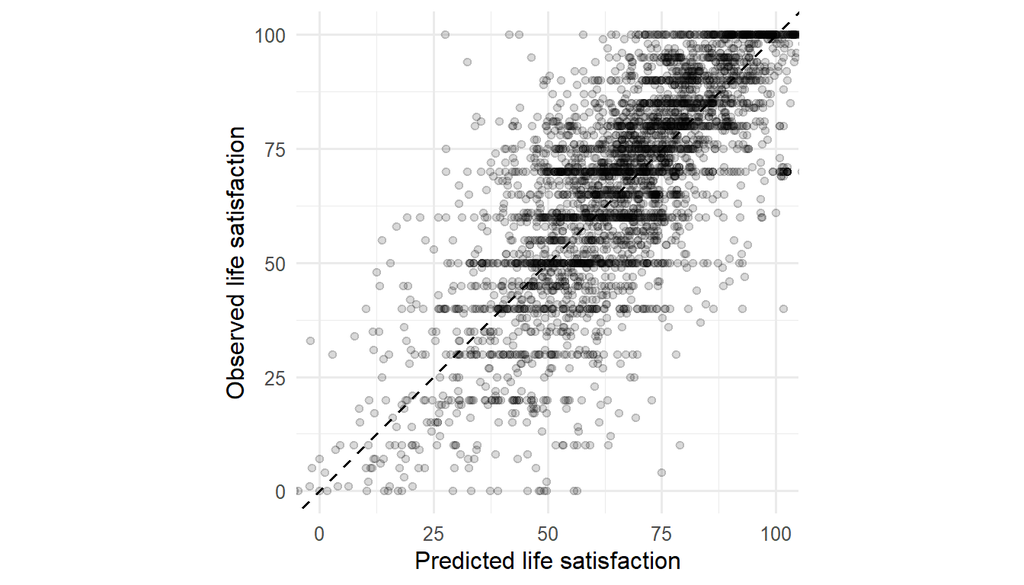

Observed against predicted life satisfaction, test days.

```r
ggplot(test_pred, aes(predicted, observed)) +
  geom_point(alpha = 0.15) +
  geom_abline(linetype = "dashed") +
  coord_equal(xlim = c(0, 100), ylim = c(0, 100)) +
  labs(x = "Predicted life satisfaction", y = "Observed life satisfaction")
```

```r
# the final model's cross-validated metrics across the folds, for comparison
final_folds <- final_fit$resample
round(sapply(final_folds[c("RMSE", "Rsquared", "MAE")], range), 3)
```

```
##        RMSE Rsquared    MAE
## [1,] 12.811    0.542  9.679
## [2,] 16.566    0.757 12.058
```

**The test result.** The final model was run once on the 3,730 test days, from people it never saw in training.

- **RMSE** 14.79 on the test days, against 14.63 in cross-validation. **R²** 0.575 against 0.623, and **MAE** 11.12 against 11.12.
- All three are inside the range of the 10 folds (RMSE 12.81 to 16.57, R² 0.542 to 0.757). The cross-validated estimate held up on new people.
- Predicting the training mean for every test day gives an RMSE of 22.43 (the SD of life satisfaction in the test days is 22.39). The final model’s typical error is 34% smaller.
- A typical error of about 11 points on the 0 to 100 scale is enough to flag days that are likely to be low. It is too coarse to rank two days that are close.

## Variable importance

```r
vi <- varImp(final_fit)
vi_table <- vi$importance %>%
  tibble::rownames_to_column("predictor") %>%
  rename(importance = Overall) %>%
  arrange(desc(importance))
head(vi_table, 20) %>% mutate(importance = round(importance, 1))
```

| predictor | importance |
| --- | --- |
| need_satisfaction | 100.0 |
| need_frustration | 56.8 |
| sleep_quality | 31.7 |
| stress_worst_1 | 16.0 |
| age | 9.1 |
| cares_for_children_Yes | 7.0 |
| education | 7.0 |
| employment_Not.employed | 6.6 |
| employment_Not.reported | 5.8 |
| gender_Woman | 5.6 |
| relationship_Partnered | 5.3 |
| gaming_wish_else | 4.5 |
| stress_worst_2 | 3.9 |
| cares_for_children_Not.reported | 3.3 |
| stress_health_Yes | 2.9 |
| play_context_Friends.only | 2.5 |
| game_type_Non.competitive | 2.2 |
| stress_discrimination_Yes | 1.8 |
| gaming_relationships | 1.7 |
| stress_work_school_Yes | 1.7 |

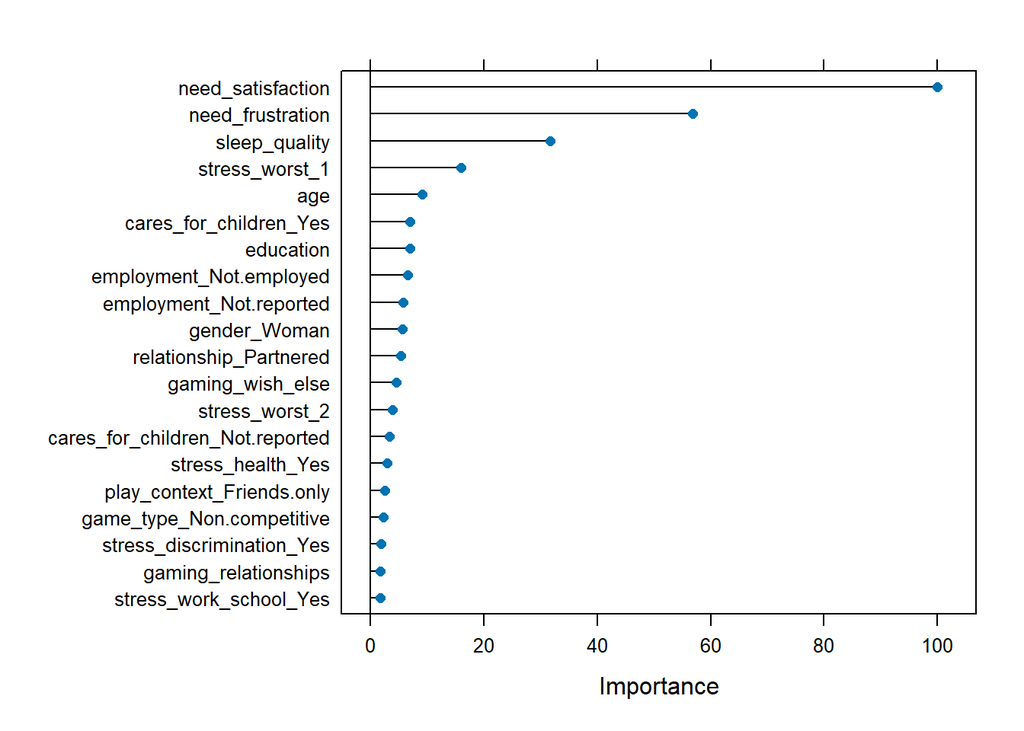

Variable importance of the final model (top 20).

```r
plot(vi, top = 20)
```

For `glmnet`, `varImp()` is the absolute value of each coefficient, scaled so the largest is 100. The recipe standardized every numeric predictor, so the coefficients are comparable.

# 10. Compare and Interpret

**Did the unsupervised features help?** Look at the A versus B table in Section 8:

- For every model, compare `A_minus_B` with `two_SE` (a positive `A_minus_B` means set B had the lower RMSE). Set B was within fold-to-fold noise of set A for every model.
- Set B swaps six needs items for two scores and adds a three-level play-day type. Set B matches set A, so the two components carry what the six items carry, in a third of the columns.
- The play-day type adds nothing on top of the BANGS items it was built from, because both sets keep those items. The check in Section 8 shows the elastic net does as well without it, at any K.

**Do the clusters and components mean something for the research question?**

- Need satisfaction is the strongest single correlate of life satisfaction in the training days (r = 0.66).
- Frustrating play days have the lowest mean life satisfaction.
- The final model leans on the components. Its two largest coefficients (Section 8) are need satisfaction (13.2 points per SD) and need frustration (-7.5). The penalty set both play-day-type columns to zero. The variable importance in Section 9 shows the same ranking.

**What a model of days can tell the users, and what it cannot.**

- *What it can tell them.* A well-being check-in could combine a few in-game questions with a short needs check. It would flag days that are likely to be low in life satisfaction for that player. A frustrating play day is one marker.
- *What it cannot tell them.* About 73% of the variation in life satisfaction is between people. A model of days cannot say which players are generally less satisfied with their lives, or why. That question needs a model of people, with person-level averages and traits as the unit.
- *Same-day caveat.* Because every predictor is from the same day, the model describes what goes together. It does not forecast tomorrow.

**Which model to hand over, and what is lost.**

- The final model is the Elastic net on set B. It also had the lowest cross-validated RMSE, so no accuracy was given up for readability.
- It can be shared as a list of coefficients, with the direction and size of every effect. Nothing is lost in interpretability.
- The random forest did slightly worse (best cross-validated RMSE 14.84, against 14.63), and it would give users only importance rankings.

# 11. Save the Results

```r
results <- list(
  counts = counts, solo_rule = solo_rule, split_sizes = split_sizes, icc = icc, n_folds = n_folds,
  miss_table = miss_table, intake_missing = intake_missing, var_table = var_table,
  k_choice = k_choice, k_final = k_final, cluster_names = cluster_names,
  cluster_profile = cluster_profile(km$cluster), km = km,
  n_comp_rules = n_comp_rules, n_keep = n_keep, loadings = loadings,
  rotated = rotated, comp_names = comp_names,
  k_profiles = k_profiles, k_stability_table = k_stability_table,
  check_k_table = check_k_table, type_coefs = type_coefs,
  pc_communality = pc_communality, check_pc_table = check_pc_table,
  set_A = set_A, set_B = set_B,
  cv_table = cv_table, cv_long = cv_long, ab = ab, a_vs_b = a_vs_b,
  best_tune = lapply(fits, `[[`, "bestTune"),
  edges = lapply(fits[-1], edge_check),
  final_key = final_key)

if (exists("final_coefs")) {
  results$final_coefs <- final_coefs
  results$stress_level_effects <- stress_level_effects
}

if (run_test_set) {
  results$test_perf <- test_perf
  results$null_test <- null_test
  results$test_pred <- test_pred
  results$vi_table  <- vi_table
}

saveRDS(results, out_path("final_results.rds"))

# all models are fit; shut down the parallel workers
stopCluster(cl)
registerDoSEQ()
```

# 12. Software

The package versions this file ran with, for the References section and for reproducing the results.